# 2024 RA STAT3 Manuscript Analysis

2024-01-10

# SETUP

```r
library(tidyverse)
library(readxl)
library(openxlsx)
library(rstatix)
library(writexl)
library(modelr)
library(nnet)
library(ggeffects)
RA<- read_excel("2024 STAT3 Manuscript R.xlsx", na=c("", "na"))
RA
```

```
## # A tibble: 98 × 42
##    ...1  `Patient #` `Current Age` Gender Ethnicity - standard nom…¹ `Age at Dx`
##    <chr>       <dbl>         <dbl> <chr>  <chr>                      <chr>
##  1 n               1            36 f      Caucasian                  27
##  2 n               5            51 f      Caucasian                  32
##  3 n               6            62 f      African American           57
##  4 n               8            28 f      Caucasian                  17
##  5 n               9            59 f      Caucasian                  <NA>
##  6 n              10            54 m      African American           52
##  7 n              14            31 f      Caucasian                  17
##  8 n              15            65 f      Caucasian                  <NA>
##  9 n              17            74 f      Caucasian                  69
## 10 n              22            57 f      Caucasian                  56
## # ℹ 88 more rows
## # ℹ abbreviated name: ¹`Ethnicity - standard nomenclature`
## # ℹ 36 more variables: `Time since dx (in years)` <dbl>,
## #   `onset of symptoms wks/months` <chr>,
## #   `Erosive disease standard nomenclature (Y/N/U)` <chr>, `CDAI score` <chr>,
## #   `Scale (CDAI or DAS28)` <chr>, `descriptive score` <chr>, SJ <dbl>,
## #   TJ <dbl>, `pt global` <chr>, `pro global` <chr>, `RF +` <chr>, …
```

```r
uvanorm <- read_excel("4-30-23 9 Normal Controls Demographics and VAFs.xlsx")
uvanorm
```

```
## # A tibble: 9 × 8
##   `Donor ID`   Age Gender Ethnicity `Blood type` Date                `Y640F VAF`
##   <chr>      <dbl> <chr>  <chr>     <chr>        <dttm>                    <dbl>
## 1 KP47636       31 Male   Hispanic  B+           2016-08-02 00:00:00       0.004
## 2 KP47641       33 Male   Hispanic  O+           2016-08-02 00:00:00       0
## 3 KP47775       55 Male   African … B+           2016-08-17 00:00:00       0
## 4 KP47776       29 Male   Hispanic  B+           2016-08-17 00:00:00       0.004
## 5 KP47777       31 Female African … B+           2016-08-17 00:00:00       0
## 6 KP47779       44 Male   African … O+           2016-08-17 00:00:00       0.088
## 7 KP47782       35 Male   Caucasian AB+          2016-08-17 00:00:00       0
## 8 KP47633       35 Male   African … A+           2016-08-02 00:00:00       0
## 9 KP47634       33 Male   Caucasian A+           2016-08-02 00:00:00       0
## # ℹ 1 more variable: `D661Y VAF` <dbl>
```

```r
valori <- read_excel("4-30-23 Valori overall cohort with VAFs.xlsx")
valori
```

```
## # A tibble: 99 × 23
##    ID    `case/control` sex     age Classification `CSF examination` `brain MRI`
##    <chr> <chr>          <chr> <dbl> <chr>          <chr>             <chr>
##  1 STC-… control        F        38 Volunteer      <NA>              <NA>
##  2 STC-… control        M        35 Volunteer      <NA>              <NA>
##  3 ST-8… control        F        23 Paresthesiae … normal, OCB-      normal
##  4 STC-… control        F        39 Volunteer      <NA>              <NA>
##  5 STC-… control        F        20 Volunteer      <NA>              <NA>
##  6 STC-… control        F        39 Volunteer      <NA>              <NA>
##  7 ST-0… control        F        59 Volunteer      <NA>              <NA>
##  8 STC-… control        M        54 Volunteer      <NA>              <NA>
##  9 STC-… control        M        61 Blood donor    <NA>              <NA>
## 10 STC-… control        F        65 Blood donor    <NA>              <NA>
## # ℹ 89 more rows
## # ℹ 16 more variables: `other MRI` <chr>, ...9 <chr>, `Avg Y640F VAF` <dbl>,
## #   `Avg D661Y VAF` <dbl>, `Allelic Fraction...12` <dbl>,
## #   `Protein Position...13` <dbl>, `Amino Acids...14` <chr>,
## #   `Allelic Fraction...15` <dbl>, `Protein Position...16` <dbl>,
## #   `Amino Acids...17` <chr>, `Allelic Fraction...18` <dbl>,
## #   `Protein Position...19` <lgl>, `Amino Acids...20` <lgl>, …
```

# Clean the Data

need to rename a lot of chi square columns

```r
RA<- RA %>%
  rename("Mutation"=...1,
         "age" = `Current Age`,
         "pt_global"=`pt global`,
         "pro_global" = `pro global`,
         "eth" = `Ethnicity - standard nomenclature`,
         "erosive" = `Erosive disease standard nomenclature (Y/N/U)`,
         "RF" = `RF +`,
         "RFpos" = `RF 0-20 U/mL normal range, greater than 20.0 is positive)`,
         "CCP" = `CCP+`,
         "CCPpos"= `Cyclic citrullinated peptide IgG (greater than 3.0 U/mL is positive)`,
         "hopCCP" = `hopkins ccp`,
         "hopCCPpos" = `hopkins ccp positivity (cutoff >20 pos)`,
         "CRPpos" = `C-reactive protein (<10mg/L normal) greater than 10.0 is positive`,
         "ESRpos" = `ESR (less than 22 mm/hr for men and less than 29 mm/hr for women is negative)`,
         "txnum" = `# of treatments (current + past)`,
         "tnf" = `TNF Exposure`,
         "mtx" = `Prior use of MTX (Y/N)`,
         "mtxnow" = `Currently on MTX`,
         "mtxb4" = `Previously on MTX`,
         "RFnum" = `RF numerical`,
         "CCPnum" = `CCP numerical`,
         "RAtime" = `Time since dx (in years)`,
         "descriptive" = `descriptive score`)
```

show examples of what the imported excel of RA patient data contains

```r
glimpse(RA)
```

```
## Rows: 98
## Columns: 42
## $ Mutation                         <chr> "n", "n", "n", "n", "n", "n", "n", "n…
## $ `Patient #`                      <dbl> 1, 5, 6, 8, 9, 10, 14, 15, 17, 22, 23…
## $ age                              <dbl> 36, 51, 62, 28, 59, 54, 31, 65, 74, 5…
## $ Gender                           <chr> "f", "f", "f", "f", "f", "m", "f", "f…
## $ eth                              <chr> "Caucasian", "Caucasian", "African Am…
## $ `Age at Dx`                      <chr> "27", "32", "57", "17", NA, "52", "17…
## $ RAtime                           <dbl> 9, 19, 5, 11, NA, 2, 14, NA, 5, 1, 6,…
## $ `onset of symptoms wks/months`   <chr> NA, "months", "years/ palindromic", N…
## $ erosive                          <chr> "N", "N", "Y", "Y", "Y", "Y", "N", "Y…
## $ `CDAI score`                     <chr> "3", "DAS - 3.38", "DAS - 1.88", "DAS…
## $ `Scale (CDAI or DAS28)`          <chr> "CDAI - ?", "DAS", "DAS", "DAS", "DAS…
## $ descriptive                      <chr> "low", "moderate", "remission", "remi…
## $ SJ                               <dbl> 0, 2, 0, 0, 0, 4, 0, 1, 0, 2, 0, 0, N…
```

[output cut: 29 more lines]

several columns have the word none, and we’ve coded to be an empty cell

```r
RA %>%
  select(contains("global"))
```

```
## # A tibble: 98 × 2
##    pt_global pro_global
##    <chr>     <chr>
##  1 2         1
##  2 50        <NA>
##  3 45        <NA>
##  4 10        <NA>
##  5 50        <NA>
##  6 <NA>      <NA>
##  7 <NA>      <NA>
##  8 70        <NA>
##  9 <NA>      <NA>
## 10 50        <NA>
## # ℹ 88 more rows
```

```r
RA %>%
  count(pro_global)
```

```
## # A tibble: 13 × 2
##    pro_global     n
##    <chr>      <int>
##  1 0              8
##  2 1             20
##  3 10             1
##  4 2             11
##  5 3              7
##  6 4              8
##  7 5              2
##  8 5.6            1
##  9 6              2
## 10 7              2
## 11 8              1
## 12 none           5
## 13 <NA>          30
```

```r
RA <- RA %>%
  mutate(across(contains("global"), ~if_else(.x=="none", NA_character_, .x))) %>%
  mutate(across(contains("global"), as.numeric))
```

clean Gender so the m and f are all lower case

```r
RA <- RA %>%
  mutate(Gender = if_else(Gender == "f"| Gender == "F", "f", "m"))
```

clean mtx so no = n and yes = y, and it’s not mixed

```r
RA <- RA %>%
  mutate(mtx = if_else(mtx == "n"| mtx == "no", "n", "y", "yes"))
```

Clean Erosive to set U as missing

```r
RA <- RA %>%
  mutate(erosive = if_else(erosive == "U", NA_character_, erosive))
```

Clean CCP to set characters as missing

```r
RA <- RA %>%
  mutate(CCP = if_else(CCP == "None", NA_character_, CCP)) %>%
  mutate(CCP = if_else(CCP == "not done per UVA note", NA_character_, CCP)) %>%
  mutate(CCP = if_else(CCP == "See note?", NA_character_, CCP))
```

clean up D661Y FA column edited from original code to get rid of parse

```r
RA %>%
  select(`D661Y FA`)
```

```
## # A tibble: 98 × 1
##    `D661Y FA`
##         <dbl>
##  1      0
##  2      0
##  3      0
##  4      0
##  5      0
##  6      0
##  7      0.046
##  8      0
##  9      0
## 10      0
## # ℹ 88 more rows
```

```r
#try parse_number
RA %>%
  mutate(D661Y = `D661Y FA`)%>%
  select(`D661Y FA`, D661Y)
```

```
## # A tibble: 98 × 2
##    `D661Y FA` D661Y
##         <dbl> <dbl>
##  1      0     0
##  2      0     0
##  3      0     0
##  4      0     0
##  5      0     0
##  6      0     0
##  7      0.046 0.046
##  8      0     0
##  9      0     0
## 10      0     0
## # ℹ 88 more rows
```

```r
RA <- RA %>%
  mutate(D661Y = `D661Y FA`)
```

create type of mutation column

```r
RA %>%
  mutate(muttype = case_when(D661Y >= 0.05& `Y640F FA` >= 0.05 ~ NA_character_,
                             D661Y >= 0.05 ~ "D661Y",
                             `Y640F FA` >= 0.05~ "Y640F",
                             TRUE ~ "WT")) %>%
  count(muttype)
```

```
## # A tibble: 4 × 2
##   muttype     n
##   <chr>   <int>
## 1 D661Y       6
## 2 WT         82
## 3 Y640F       8
## 4 <NA>        2
```

```r
RA <- RA %>%
  mutate(muttype = case_when(D661Y >= 0.05& `Y640F FA` >= 0.05 ~ NA_character_,
                             D661Y >= 0.05 ~ "D661Y",
                             `Y640F FA` >= 0.05~ "Y640F",
                             TRUE ~ "WT"))
```

create type of mutation column with >0.008 lowvaf cutoff

```r
RA %>%
  mutate(muttypelow = case_when(D661Y >= 0.008& `Y640F FA` >= 0.008 ~ NA_character_,
                             D661Y >= 0.008 ~ "D661Y",
                             `Y640F FA` >= 0.008~ "Y640F",
                             TRUE ~ "WT")) %>%
  count(muttypelow)
```

```
## # A tibble: 4 × 2
##   muttypelow     n
##   <chr>      <int>
## 1 D661Y         11
## 2 WT            46
## 3 Y640F         27
## 4 <NA>          14
```

```r
RA <- RA %>%
  mutate(muttypelow = case_when(D661Y >= 0.008& `Y640F FA` >= 0.008 ~ NA_character_,
                             D661Y >= 0.008 ~ "D661Y",
                             `Y640F FA` >= 0.008~ "Y640F",
                             TRUE ~ "WT"))
```

create just mutant column

```r
RA %>%
  mutate(muts = case_when(D661Y >= 0.05& `Y640F FA` >= 0.05 ~ NA_character_,
                             D661Y >= 0.05 ~ "D661Y",
                             `Y640F FA` >= 0.05~ "Y640F",
                             TRUE ~ NA_character_)) %>%
  count(muts)
```

```
## # A tibble: 3 × 2
##   muts      n
##   <chr> <int>
## 1 D661Y     6
## 2 Y640F     8
## 3 <NA>     84
```

```r
RA <- RA %>%
  mutate(muts = case_when(D661Y >= 0.05& `Y640F FA` >= 0.05 ~ NA_character_,
                             D661Y >= 0.05 ~ "D661Y",
                             `Y640F FA` >= 0.05~ "Y640F",
                             TRUE ~ NA_character_))
```

create just mutant column with 0.008 cutoff

```r
RA %>%
  mutate(muts008 = case_when(D661Y >= 0.008& `Y640F FA` >= 0.008 ~ NA_character_,
                             D661Y >= 0.008 ~ "D661Y",
                             `Y640F FA` >= 0.008~ "Y640F",
                             TRUE ~ NA_character_)) %>%
  count(muts008)
```

```
## # A tibble: 3 × 2
##   muts008     n
##   <chr>   <int>
## 1 D661Y      11
## 2 Y640F      27
## 3 <NA>       60
```

```r
RA <- RA %>%
  mutate(muts008 = case_when(D661Y >= 0.008& `Y640F FA` >= 0.008 ~ NA_character_,
                             D661Y >= 0.008 ~ "D661Y",
                             `Y640F FA` >= 0.008~ "Y640F",
                             TRUE ~ NA_character_))
```

create y/n mutation column for VAF>0.008

```r
RA %>%
  mutate(lowvafmut = case_when(D661Y >= 0.008 & `Y640F FA` >= 0.008 ~ "y",
                             D661Y >= 0.008 ~ "y",
                             `Y640F FA` >= 0.008~ "y",
                             TRUE ~ "n")) %>%
  count(lowvafmut)
```

```
## # A tibble: 2 × 2
##   lowvafmut     n
##   <chr>     <int>
## 1 n            46
## 2 y            52
```

```r
RA <- RA %>%
  mutate(lowvafmut = case_when(D661Y >= 0.008 & `Y640F FA` >= 0.008 ~ "y",
                             D661Y >= 0.008 ~ "y",
                             `Y640F FA` >= 0.008~ "y",
                             TRUE ~ "n"))
```

create y/n mutation column for y640f and d661y VAF>0.008

```r
RA %>%
  mutate(ymut = case_when(`Y640F FA` >= 0.008~ "y",
                             TRUE ~ "n")) %>%
  count(ymut)
```

```
## # A tibble: 2 × 2
##   ymut      n
##   <chr> <int>
## 1 n        57
## 2 y        41
```

```r
RA %>%
  mutate(dmut = case_when(   D661Y >= 0.008 ~ "y",
                             TRUE ~ "n")) %>%
  count(dmut)
```

```
## # A tibble: 2 × 2
##   dmut      n
##   <chr> <int>
## 1 n        73
## 2 y        25
```

```r
RA <- RA %>%
  mutate(ymut = case_when(`Y640F FA` >= 0.008~ "y",
                             TRUE ~ "n"))
RA <- RA %>%
  mutate(dmut = case_when(   D661Y >= 0.008 ~ "y",
                             TRUE ~ "n"))
```

create double positive column of RF and CCP

```r
RA %>%
  mutate(rfccp = case_when(RFpos == "positive" & CCPpos == "positive" ~ "positive",
                           RFpos == "negative" ~ "negative",
                           CCPpos == "negative" ~ "negative",
                           RFpos == "negative" & CCPpos == "positive" ~ "negative",
                           RFpos == "positive" & CCPpos == "negative" ~ "negative",
                             TRUE ~ NA_character_)) %>%
  count(rfccp)
```

```
## # A tibble: 3 × 2
##   rfccp        n
##   <chr>    <int>
## 1 negative    43
## 2 positive    50
## 3 <NA>         5
```

```r
RA <- RA %>%
  mutate(rfccp = case_when(RFpos == "positive" & CCPpos == "positive" ~ "positive",
                           RFpos == "negative" ~ "negative",
                           CCPpos == "negative" ~ "negative",
                           RFpos == "negative" & CCPpos == "positive" ~ "negative",
                           RFpos == "positive" & CCPpos == "negative" ~ "negative",
                             TRUE ~ NA_character_))
```

###cleaning RF column removing all less than signs and setting min to 20 because of different sensitivities of different tests

this parses the data and gets rid of anything that is not a number next to a number, so all <20 turns to 20

```r
RA <- RA %>%
  mutate(RFnumna=parse_number(RF))
```

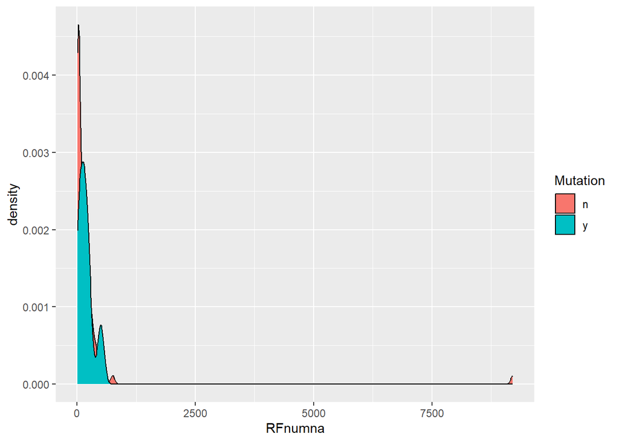

```r
RA %>%
  ggplot(aes(RFnumna, fill=Mutation)) + geom_density()
```

creating another RF variable where neg=20, positive = median of RF >20, 164.5

```r
RA %>%
  filter(RFnumna > 20) %>%
  summarise(median(RFnumna))
```

```
## # A tibble: 1 × 1
##   `median(RFnumna)`
##               <dbl>
## 1              164.
```

```r
RA %>%
  filter(RFnumna <= 20) %>%
  summarise(median(RFnumna))
```

```
## # A tibble: 1 × 1
##   `median(RFnumna)`
##               <dbl>
## 1                20
```

```r
RA <-RA %>%
  mutate(RFnum = case_when(RF == "positive" ~ 164.5,
                           RF == "neg" ~ 20,
                           TRUE~RFnumna))
```

creates a conservative column with positives set at the minimum limit of detection to be a positive

```r
RA <-RA %>%
  mutate(RFcons = case_when(RF == "positive" ~ 21,
                           RF == "neg" ~ 20,
                           TRUE~RFnumna))
```

###cleaning CCP column removing all less than signs and setting negative values to median of <3 because of different sensitivities of different tests

```r
RA <- RA %>%
  mutate(CCPnumna=parse_number(`CCP`))
```

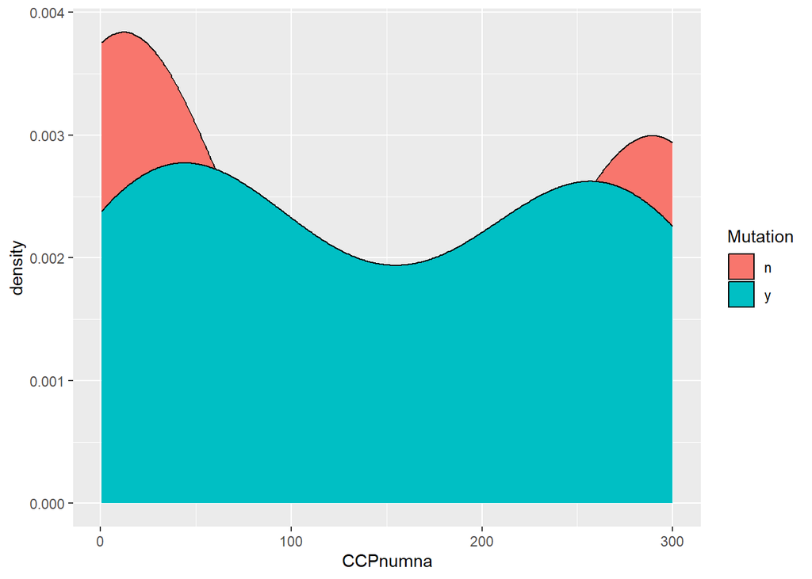

```r
RA %>%
  ggplot(aes(CCPnumna, fill=Mutation)) + geom_density()
```

creating another CCP variable where neg=median of CCP <3, 0.5 , positive = median of RF >3, 250

```r
RA %>%
  filter(CCPnumna > 3) %>%
  summarise(median(CCPnumna))
```

```
## # A tibble: 1 × 1
##   `median(CCPnumna)`
##                <dbl>
## 1                250
```

```r
RA %>%
  filter(CCPnumna <= 3) %>%
  summarise(median(CCPnumna))
```

```
## # A tibble: 1 × 1
##   `median(CCPnumna)`
##                <dbl>
## 1                0.5
```

```r
RA <- RA %>%
  mutate(CCPnum = case_when(CCP == "positive" ~ 250,
                           CCP == "neg" ~ 0.5,
                           TRUE~CCPnumna))
```

### clean normals

make vector of desired variables for normal testing

```r
norms <- c("Age", "Y640F VAF", "D661Y VAF", "Gender")
normis <-c("age", "Avg Y640F VAF", "Avg D661Y VAF", "sex")
```

test the vector

```r
uvanorm %>%
  select(all_of(norms))
```

```
## # A tibble: 9 × 4
##     Age `Y640F VAF` `D661Y VAF` Gender
##   <dbl>       <dbl>       <dbl> <chr>
## 1    31       0.004       0.004 Male
## 2    33       0           0     Male
## 3    55       0           0.004 Male
## 4    29       0.004       0     Male
## 5    31       0           0     Female
## 6    44       0.088       0     Male
## 7    35       0           0     Male
## 8    35       0           0     Male
## 9    33       0           0     Male
```

```r
valori %>%
  select(all_of(normis))
```

```
## # A tibble: 99 × 4
##      age `Avg Y640F VAF` `Avg D661Y VAF` sex
##    <dbl>           <dbl>           <dbl> <chr>
##  1    38          0               0.0762 F
##  2    35          0               0.0952 M
##  3    23          0               0      F
##  4    39          0               0      F
##  5    20          0               0      F
##  6    39          0               0      F
##  7    59          0               0      F
##  8    54          0.0781          0      M
##  9    61          0               0      M
## 10    65          0               0      F
## # ℹ 89 more rows
```

clean Gender so the m and f are all lower case

```r
uvanorm <- uvanorm %>%
  mutate(Gender = if_else(Gender == "Female", "f", Gender)) %>%
           mutate(Gender = if_else(Gender == "Male", "m", Gender))

valori <- valori %>%
  mutate(sex = if_else(sex == "F", "f", sex)) %>%
           mutate(sex = if_else(sex == "M", "m", sex))
```

create 2 clean datasets to merge together

```r
uvanormal <- uvanorm %>%
  select(all_of(norms)) %>%
  mutate(paper = "uva", status = "normal")

valoris <- valori %>%
  select(all_of(normis)) %>%
  mutate(paper = "v", status = "normal")
```

merge normal datasets always check dimensions of result for join

```r
allnorms <- uvanormal %>%
  full_join(valoris, by = c("Age"= "age", "Y640F VAF" = "Avg Y640F VAF","D661Y VAF"="Avg D661Y VAF","Gender" = "sex", "paper", "status"))

#fix names so there's no spaces
allnorms <-allnorms %>%
  rename("Y640F"=`Y640F VAF`,
         "D661Y" = `D661Y VAF`)
```

### make RA dataset for comparison to normals

```r
RAcompare <- RA %>% select(age, Gender, eth, `Y640F FA`, D661Y) %>%
  mutate(status = "RA", paper = "uva")

#join RAcompare to allnorms

alldat <- RAcompare %>%
  full_join(allnorms, by = c("age" = "Age", "Y640F FA" = "Y640F", "D661Y", "Gender", "status", "paper"))

#fix names so there's no spaces
alldat <- alldat %>%
  rename("Y640F"=`Y640F FA`)
```

create log of D661Y and Y640F constant is half of lowest value

```r
alldat <- alldat %>%
  mutate(logY640F = log(Y640F + 0.004))

alldat <- alldat %>%
  mutate(logD661Y = log(D661Y + 0.004))
```

make a column for yes no mutation

```r
alldat <- alldat %>%
  mutate(muttype = case_when(D661Y >= 0.05& Y640F >= 0.05 ~ "double",
                             D661Y >= 0.05 ~ "D661Y",
                             Y640F >= 0.05~ "Y640F",
                             TRUE ~ "WT"))

#count(muttype)

alldat <- alldat %>%
  mutate(lowvafmut = case_when(D661Y >= 0.005& Y640F >= 0.005 ~ "double",
                             D661Y >= 0.005 ~ "D661Y",
                             Y640F >= 0.005~ "Y640F",
                             TRUE ~ "WT"))
#count(lowvafmut)
```

# Chi Square testing by Mutation Y/N

need to run Gender, eth, erosive, hopCCPpos, CCPpos, ESRpos, RFpos, rfccp, mtx, mtxnow, mtxb4, descriptive, tnf

checking how clean each variable is

```r
RA %>%
  count(`descriptive`)
```

```
## # A tibble: 5 × 2
##   descriptive     n
##   <chr>       <int>
## 1 high            9
## 2 low            34
## 3 moderate       21
## 4 remission      28
## 5 <NA>            6
```

```r
xtabs(~CCPpos + Mutation, data = RA)
```

```
##           Mutation
## CCPpos      n  y
##   negative 34  1
##   positive 46 12
```

### Run Gender Chi Square

```r
xtgender <- xtabs(~Gender + Mutation, data = RA)
xtgender
```

```
##       Mutation
## Gender  n  y
##      f 62 10
##      m 20  6
```

```r
#get the proportion of each gender that has a mutation
prop.table(xtgender, 1)
```

```
##       Mutation
## Gender         n         y
##      f 0.8611111 0.1388889
##      m 0.7692308 0.2307692
```

```r
set.seed(83)
chisq.test(xtgender, simulate.p.value = TRUE)
```

```
##
##  Pearson's Chi-squared test with simulated p-value (based on 2000
##  replicates)
##
## data:  xtgender
## X-squared = 1.1804, df = NA, p-value = 0.3723
```

```r
# assumption of chi square is that expected values are all bigger than 1, see expected values
chisq.test(xtgender, simulate.p.value = TRUE)$expected
```

```
##       Mutation
## Gender       n         y
##      f 60.2449 11.755102
##      m 21.7551  4.244898
```

### Run all Chi Square Tests

```r
myvars<-c("Gender", "eth", "erosive", "hopCCPpos", "CCPpos", "ESRpos", "mtx", "mtxnow", "mtxb4",  "RFpos", "rfccp", "descriptive","tnf" )
```

test the vector

```r
RA %>% select(all_of(myvars))
```

```
## # A tibble: 98 × 13
##    Gender eth     erosive hopCCPpos CCPpos ESRpos mtx   mtxnow mtxb4 RFpos rfccp
##    <chr>  <chr>   <chr>   <chr>     <chr>  <chr>  <chr> <chr>  <chr> <chr> <chr>
##  1 f      Caucas… N       pos       posit… negat… n     n      n     nega… nega…
##  2 f      Caucas… N       pos       posit… posit… y     y      n     posi… posi…
##  3 f      Africa… Y       pos       posit… posit… n     n      n     posi… posi…
##  4 f      Caucas… Y       neg       negat… negat… y     n      y     nega… nega…
##  5 f      Caucas… Y       neg       negat… negat… y     y      n     nega… nega…
##  6 m      Africa… Y       pos       posit… posit… y     y      n     posi… posi…
##  7 f      Caucas… N       neg       negat… negat… y     y      n     nega… nega…
##  8 f      Caucas… Y       pos       posit… negat… y     n      y     posi… posi…
##  9 f      Caucas… Y       pos       posit… posit… y     n      y     posi… posi…
## 10 f      Caucas… N       pos       negat… negat… y     y      n     posi… nega…
## # ℹ 88 more rows
## # ℹ 2 more variables: descriptive <chr>, tnf <chr>
```

check count on each variable

```r
RA %>%
  count(mtx)
```

```
## # A tibble: 2 × 2
##   mtx       n
##   <chr> <int>
## 1 n        14
## 2 y        84
```

make a long form dataset with all vars in one column for .05, .008, and y640f .008, and d661y .008 cutoffs

```r
RAlong <- RA %>%
  select(all_of(myvars), Mutation) %>%
  pivot_longer(Gender:tnf, names_to = "var", values_to = "values")

RAlong
```

```
## # A tibble: 1,274 × 3
##    Mutation var       values
##    <chr>    <chr>     <chr>
##  1 n        Gender    f
##  2 n        eth       Caucasian
##  3 n        erosive   N
##  4 n        hopCCPpos pos
##  5 n        CCPpos    positive
##  6 n        ESRpos    negative
##  7 n        mtx       n
##  8 n        mtxnow    n
##  9 n        mtxb4     n
## 10 n        RFpos     negative
## # ℹ 1,264 more rows
```

```r
Ralong008 <- RA %>%
  select(all_of(myvars), lowvafmut) %>%
  pivot_longer(Gender:tnf, names_to = "var", values_to = "values")

Ralong008
```

```
## # A tibble: 1,274 × 3
##    lowvafmut var       values
##    <chr>     <chr>     <chr>
##  1 n         Gender    f
##  2 n         eth       Caucasian
##  3 n         erosive   N
##  4 n         hopCCPpos pos
##  5 n         CCPpos    positive
##  6 n         ESRpos    negative
##  7 n         mtx       n
##  8 n         mtxnow    n
##  9 n         mtxb4     n
## 10 n         RFpos     negative
## # ℹ 1,264 more rows
```

```r
Ralongy <- RA %>%
  select(all_of(myvars), ymut) %>%
  pivot_longer(Gender:tnf, names_to = "var", values_to = "values")

Ralongy
```

```
## # A tibble: 1,274 × 3
##    ymut  var       values
##    <chr> <chr>     <chr>
##  1 n     Gender    f
##  2 n     eth       Caucasian
##  3 n     erosive   N
##  4 n     hopCCPpos pos
##  5 n     CCPpos    positive
##  6 n     ESRpos    negative
##  7 n     mtx       n
##  8 n     mtxnow    n
##  9 n     mtxb4     n
## 10 n     RFpos     negative
## # ℹ 1,264 more rows
```

```r
Ralongd <- RA %>%
  select(all_of(myvars), dmut) %>%
  pivot_longer(Gender:tnf, names_to = "var", values_to = "values")

Ralongd
```

```
## # A tibble: 1,274 × 3
##    dmut  var       values
##    <chr> <chr>     <chr>
##  1 n     Gender    f
##  2 n     eth       Caucasian
##  3 n     erosive   N
##  4 n     hopCCPpos pos
##  5 n     CCPpos    positive
##  6 n     ESRpos    negative
##  7 n     mtx       n
##  8 n     mtxnow    n
##  9 n     mtxb4     n
## 10 n     RFpos     negative
## # ℹ 1,264 more rows
```

```r
set.seed(83)
RAlong %>%
  group_by(var) %>%
  summarise(xtab = list(xtabs(~values + Mutation))) %>%
  mutate(chisq = map(xtab,~chisq_test(.x, simulate.p.value = TRUE))) %>%
  unnest(cols = chisq) %>%
  arrange(p)
```

```
## # A tibble: 13 × 8
##    var         xtab                n statistic      p df    method      p.signif
##    <chr>       <list>          <int>     <dbl>  <dbl> <lgl> <chr>       <chr>
##  1 rfccp       <xtabs [2 × 2]>    93    5.79   0.016  NA    Chi-square… *
##  2 CCPpos      <xtabs [2 × 2]>    93    5.77   0.031  NA    Chi-square… *
##  3 RFpos       <xtabs [2 × 2]>    98    4.83   0.0465 NA    Chi-square… *
##  4 eth         <xtabs [3 × 2]>    98    3.46   0.165  NA    Chi-square… ns
##  5 hopCCPpos   <xtabs [2 × 2]>    98    2.17   0.216  NA    Chi-square… ns
##  6 Gender      <xtabs [2 × 2]>    98    1.18   0.334  NA    Chi-square… ns
##  7 mtxb4       <xtabs [2 × 2]>    98    0.692  0.579  NA    Chi-square… ns
##  8 erosive     <xtabs [2 × 2]>    97    0.607  0.583  NA    Chi-square… ns
##  9 mtxnow      <xtabs [2 × 2]>    98    0.404  0.605  NA    Chi-square… ns
## 10 tnf         <xtabs [2 × 2]>    98    0.291  0.782  NA    Chi-square… ns
## 11 descriptive <xtabs [4 × 2]>    92    1.04   0.791  NA    Chi-square… ns
## 12 ESRpos      <xtabs [2 × 2]>    97    0.0787 1      NA    Chi-square… ns
## 13 mtx         <xtabs [2 × 2]>    98    0.0498 1      NA    Chi-square… ns
```

```r
set.seed(83)
Ralong008 %>%
  group_by(var) %>%
  summarise(xtab = list(xtabs(~values + lowvafmut))) %>%
  mutate(chisq = map(xtab,~chisq_test(.x, simulate.p.value = TRUE))) %>%
  unnest(cols = chisq) %>%
  arrange(p)
```

```
## # A tibble: 13 × 8
##    var         xtab                n statistic     p df    method       p.signif
##    <chr>       <list>          <int>     <dbl> <dbl> <lgl> <chr>        <chr>
##  1 CCPpos      <xtabs [2 × 2]>    93  3.03     0.101 NA    Chi-square … ns
##  2 rfccp       <xtabs [2 × 2]>    93  3.05     0.104 NA    Chi-square … ns
##  3 hopCCPpos   <xtabs [2 × 2]>    98  2.27     0.18  NA    Chi-square … ns
##  4 eth         <xtabs [3 × 2]>    98  3.02     0.198 NA    Chi-square … ns
##  5 RFpos       <xtabs [2 × 2]>    98  1.70     0.213 NA    Chi-square … ns
##  6 descriptive <xtabs [4 × 2]>    92  3.01     0.396 NA    Chi-square … ns
##  7 mtx         <xtabs [2 × 2]>    98  0.826    0.412 NA    Chi-square … ns
##  8 erosive     <xtabs [2 × 2]>    97  0.415    0.547 NA    Chi-square … ns
##  9 mtxnow      <xtabs [2 × 2]>    98  0.384    0.573 NA    Chi-square … ns
## 10 Gender      <xtabs [2 × 2]>    98  0.133    0.824 NA    Chi-square … ns
## 11 tnf         <xtabs [2 × 2]>    98  0.111    0.846 NA    Chi-square … ns
## 12 ESRpos      <xtabs [2 × 2]>    97  0.00115  1     NA    Chi-square … ns
## 13 mtxb4       <xtabs [2 × 2]>    98  0.000301 1     NA    Chi-square … ns
```

```r
set.seed(83)
Ralongy %>%
  group_by(var) %>%
  summarise(xtab = list(xtabs(~values + ymut))) %>%
  mutate(chisq = map(xtab,~chisq_test(.x, simulate.p.value = TRUE))) %>%
  unnest(cols = chisq) %>%
  arrange(p)
```

```
## # A tibble: 13 × 8
##    var         xtab                n statistic     p df    method       p.signif
##    <chr>       <list>          <int>     <dbl> <dbl> <lgl> <chr>        <chr>
##  1 hopCCPpos   <xtabs [2 × 2]>    98   5.89    0.021 NA    Chi-square … *
##  2 rfccp       <xtabs [2 × 2]>    93   3.74    0.06  NA    Chi-square … ns
##  3 CCPpos      <xtabs [2 × 2]>    93   3.51    0.091 NA    Chi-square … ns
##  4 RFpos       <xtabs [2 × 2]>    98   2.98    0.098 NA    Chi-square … ns
##  5 mtxb4       <xtabs [2 × 2]>    98   1.43    0.284 NA    Chi-square … ns
##  6 descriptive <xtabs [4 × 2]>    92   3.61    0.309 NA    Chi-square … ns
##  7 eth         <xtabs [3 × 2]>    98   2.19    0.468 NA    Chi-square … ns
##  8 mtxnow      <xtabs [2 × 2]>    98   0.618   0.562 NA    Chi-square … ns
##  9 mtx         <xtabs [2 × 2]>    98   0.252   0.775 NA    Chi-square … ns
## 10 tnf         <xtabs [2 × 2]>    98   0.167   0.841 NA    Chi-square … ns
## 11 ESRpos      <xtabs [2 × 2]>    97   0.0802  0.844 NA    Chi-square … ns
## 12 Gender      <xtabs [2 × 2]>    98   0.00323 1     NA    Chi-square … ns
## 13 erosive     <xtabs [2 × 2]>    97   0.00150 1     NA    Chi-square … ns
```

```r
set.seed(83)
Ralongd %>%
  group_by(var) %>%
  summarise(xtab = list(xtabs(~values + dmut))) %>%
  mutate(chisq = map(xtab,~chisq_test(.x, simulate.p.value = TRUE))) %>%
  unnest(cols = chisq) %>%
  arrange(p)
```

```
## # A tibble: 13 × 8
##    var         xtab                n statistic     p df    method       p.signif
##    <chr>       <list>          <int>     <dbl> <dbl> <lgl> <chr>        <chr>
##  1 CCPpos      <xtabs [2 × 2]>    93   3.99    0.077 NA    Chi-square … ns
##  2 rfccp       <xtabs [2 × 2]>    93   3.41    0.087 NA    Chi-square … ns
##  3 RFpos       <xtabs [2 × 2]>    98   2.34    0.143 NA    Chi-square … ns
##  4 eth         <xtabs [3 × 2]>    98   3.36    0.186 NA    Chi-square … ns
##  5 descriptive <xtabs [4 × 2]>    92   4.70    0.199 NA    Chi-square … ns
##  6 mtx         <xtabs [2 × 2]>    98   0.895   0.511 NA    Chi-square … ns
##  7 mtxnow      <xtabs [2 × 2]>    98   0.662   0.514 NA    Chi-square … ns
##  8 tnf         <xtabs [2 × 2]>    98   0.232   0.641 NA    Chi-square … ns
##  9 hopCCPpos   <xtabs [2 × 2]>    98   0.212   0.797 NA    Chi-square … ns
## 10 Gender      <xtabs [2 × 2]>    98   0.110   0.803 NA    Chi-square … ns
## 11 erosive     <xtabs [2 × 2]>    97   0.106   0.82  NA    Chi-square … ns
## 12 ESRpos      <xtabs [2 × 2]>    97   0.00674 1     NA    Chi-square … ns
## 13 mtxb4       <xtabs [2 × 2]>    98   0.0253  1     NA    Chi-square … ns
```

make datasets containing all p values

```r
set.seed(83)
Pchi <-
RAlong %>%
  group_by(var) %>%
  summarise(xtab = list(xtabs(~values + Mutation))) %>%
  mutate(chisq = map(xtab,~chisq_test(.x, simulate.p.value = TRUE))) %>%
  unnest(cols = chisq) %>%
  arrange(p)

set.seed(83)
Pchi008 <-
Ralong008 %>%
  group_by(var) %>%
  summarise(xtab = list(xtabs(~values + lowvafmut))) %>%
  mutate(chisq = map(xtab,~chisq_test(.x, simulate.p.value = TRUE))) %>%
  unnest(cols = chisq) %>%
  arrange(p)

set.seed(83)
Pchiy <-
Ralongy %>%
  group_by(var) %>%
  summarise(xtab = list(xtabs(~values + ymut))) %>%
  mutate(chisq = map(xtab,~chisq_test(.x, simulate.p.value = TRUE))) %>%
  unnest(cols = chisq) %>%
  arrange(p)

set.seed(83)
Pchid <-
Ralongd %>%
  group_by(var) %>%
  summarise(xtab = list(xtabs(~values + dmut))) %>%
  mutate(chisq = map(xtab,~chisq_test(.x, simulate.p.value = TRUE))) %>%
  unnest(cols = chisq) %>%
  arrange(p)
```

adjust p values for multiple testing

```r
set.seed(83)
RAlong %>%
  group_by(var) %>%
  summarise(xtab = list(xtabs(~values + Mutation))) %>%
  mutate(chisq = map(xtab,~chisq_test(.x, simulate.p.value = TRUE))) %>%
  unnest(cols = chisq) %>%
  mutate(p.adj = p.adjust(p, method = "holm"))%>%
  arrange(p.adj)
```

```
## # A tibble: 13 × 9
##    var         xtab           n statistic      p df    method     p.signif p.adj
##    <chr>       <list>     <int>     <dbl>  <dbl> <lgl> <chr>      <chr>    <dbl>
##  1 rfccp       <xtabs[…]>    93    5.79   0.016  NA    Chi-squar… *        0.208
##  2 CCPpos      <xtabs[…]>    93    5.77   0.031  NA    Chi-squar… *        0.372
##  3 RFpos       <xtabs[…]>    98    4.83   0.0465 NA    Chi-squar… *        0.511
##  4 ESRpos      <xtabs[…]>    97    0.0787 1      NA    Chi-squar… ns       1
##  5 Gender      <xtabs[…]>    98    1.18   0.334  NA    Chi-squar… ns       1
##  6 descriptive <xtabs[…]>    92    1.04   0.791  NA    Chi-squar… ns       1
##  7 erosive     <xtabs[…]>    97    0.607  0.583  NA    Chi-squar… ns       1
##  8 eth         <xtabs[…]>    98    3.46   0.165  NA    Chi-squar… ns       1
##  9 hopCCPpos   <xtabs[…]>    98    2.17   0.216  NA    Chi-squar… ns       1
## 10 mtx         <xtabs[…]>    98    0.0498 1      NA    Chi-squar… ns       1
## 11 mtxb4       <xtabs[…]>    98    0.692  0.579  NA    Chi-squar… ns       1
## 12 mtxnow      <xtabs[…]>    98    0.404  0.605  NA    Chi-squar… ns       1
## 13 tnf         <xtabs[…]>    98    0.291  0.782  NA    Chi-squar… ns       1
```

make datasets for adding to later excel sheet

```r
set.seed(83)
padjchi <-
RAlong %>%
  group_by(var) %>%
  summarise(xtab = list(xtabs(~values + Mutation))) %>%
  mutate(chisq = map(xtab,~chisq_test(.x, simulate.p.value = TRUE))) %>%
  unnest(cols = chisq) %>%
  mutate(p.adj = p.adjust(p, method = "holm"))%>%
  arrange(p.adj)

set.seed(83)
padjchi008 <-
Ralong008 %>%
  group_by(var) %>%
  summarise(xtab = list(xtabs(~values + lowvafmut))) %>%
  mutate(chisq = map(xtab,~chisq_test(.x, simulate.p.value = TRUE))) %>%
  unnest(cols = chisq) %>%
  mutate(p.adj = p.adjust(p, method = "holm"))%>%
  arrange(p.adj)

set.seed(83)
padjchiy <-
Ralongy %>%
  group_by(var) %>%
  summarise(xtab = list(xtabs(~values + ymut))) %>%
  mutate(chisq = map(xtab,~chisq_test(.x, simulate.p.value = TRUE))) %>%
  unnest(cols = chisq) %>%
  mutate(p.adj = p.adjust(p, method = "holm"))%>%
  arrange(p.adj)

set.seed(83)
padjchid <-
Ralongd %>%
  group_by(var) %>%
  summarise(xtab = list(xtabs(~values + dmut))) %>%
  mutate(chisq = map(xtab,~chisq_test(.x, simulate.p.value = TRUE))) %>%
  unnest(cols = chisq) %>%
  mutate(p.adj = p.adjust(p, method = "holm"))%>%
  arrange(p.adj)
```

# Chi Square testing by Mutation Type Y640F, D661Y, WT

need to run Gender, eth, erosive, hopCCPpos, CCPpos, CRPpos, ESRpos, RFpos, rfccp, mtx, mtxnow, mtxb4, tnf, descriptive score

###check single chi square by mutation type including wt category to see if it works

```r
xthopCCPpostyp <- xtabs(~hopCCPpos + muttype, data = RA)
xthopCCPpostyp
```

```
##          muttype
## hopCCPpos D661Y WT Y640F
##       neg     2 25     0
##       pos     4 57     8
```

```r
#get the proportion of each gender that has a mutation
prop.table(xthopCCPpostyp, 2)
```

```
##          muttype
## hopCCPpos     D661Y        WT     Y640F
##       neg 0.3333333 0.3048780 0.0000000
##       pos 0.6666667 0.6951220 1.0000000
```

```r
set.seed(83)
chisq.test(xthopCCPpostyp, simulate.p.value = TRUE)
```

```
##
##  Pearson's Chi-squared test with simulated p-value (based on 2000
##  replicates)
##
## data:  xthopCCPpostyp
## X-squared = 3.4374, df = NA, p-value = 0.2239
```

```r
# assumption of chi square is that expected values are all bigger than 1, see expected values
hopccpe <- chisq.test(xthopCCPpostyp, simulate.p.value = TRUE)$expected
hopccpe
```

```
##          muttype
## hopCCPpos  D661Y      WT Y640F
##       neg 1.6875 23.0625  2.25
##       pos 4.3125 58.9375  5.75
```

see the chi square contributions

```r
((xthopCCPpostyp-hopccpe)^2)/(hopccpe)
```

```
##          muttype
## hopCCPpos      D661Y         WT      Y640F
##       neg 0.05787037 0.16277100 2.25000000
##       pos 0.02264493 0.06369300 0.88043478
```

###check single chi square by mutation type minus wt category to see if it works

```r
xthopCCPposmut <- xtabs(~hopCCPpos + muts, data = RA)
xthopCCPposmut
```

```
##          muts
## hopCCPpos D661Y Y640F
##       neg     2     0
##       pos     4     8
```

```r
#get the proportion of each gender that has a mutation
prop.table(xthopCCPposmut, 2)
```

```
##          muts
## hopCCPpos     D661Y     Y640F
##       neg 0.3333333 0.0000000
##       pos 0.6666667 1.0000000
```

```r
set.seed(83)
chisq.test(xthopCCPposmut, simulate.p.value = TRUE)
```

```
##
##  Pearson's Chi-squared test with simulated p-value (based on 2000
##  replicates)
##
## data:  xthopCCPposmut
## X-squared = 3.1111, df = NA, p-value = 0.1584
```

```r
# assumption of chi square is that expected values are all bigger than 1, see expected values
hopmccpe <- chisq.test(xthopCCPposmut, simulate.p.value = TRUE)$expected
hopmccpe
```

```
##          muts
## hopCCPpos     D661Y    Y640F
##       neg 0.8571429 1.142857
##       pos 5.1428571 6.857143
```

see the chi square contributions

```r
((xthopCCPposmut-hopmccpe)^2)/(hopmccpe)
```

```
##          muts
## hopCCPpos     D661Y     Y640F
##       neg 1.5238095 1.1428571
##       pos 0.2539683 0.1904762
```

check historical ccp, because expecting to see a significant p value

```r
xtCCPposmut <- xtabs(~CCPpos + muts, data = RA)
xtCCPposmut
```

```
##           muts
## CCPpos     D661Y Y640F
##   negative     1     0
##   positive     5     7
```

```r
#get the proportion of each gender that has a mutation
prop.table(xtCCPposmut, 2)
```

```
##           muts
## CCPpos         D661Y     Y640F
##   negative 0.1666667 0.0000000
##   positive 0.8333333 1.0000000
```

```r
set.seed(83)
chisq.test(xtCCPposmut, simulate.p.value = TRUE)
```

```
##
##  Pearson's Chi-squared test with simulated p-value (based on 2000
##  replicates)
##
## data:  xtCCPposmut
## X-squared = 1.2639, df = NA, p-value = 0.4768
```

```r
# assumption of chi square is that expected values are all bigger than 1, see expected values
chisq.test(xtCCPposmut, simulate.p.value = TRUE)$expected
```

```
##           muts
## CCPpos         D661Y     Y640F
##   negative 0.4615385 0.5384615
##   positive 5.5384615 6.4615385
```

testing CRP table - expected values are too low to run chi square, remove from myvars

```r
xtCRPposmut <- xtabs(~CRPpos + Mutation, data = RA)
xtCRPposmut
```

```
##           Mutation
## CRPpos      n  y
##   negative 80 16
##   positive  2  0
```

```r
#get the proportion of each gender that has a mutation
prop.table(xtCRPposmut, 2)
```

```
##           Mutation
## CRPpos              n          y
##   negative 0.97560976 1.00000000
##   positive 0.02439024 0.00000000
```

```r
#test expected values
chisq.test(xtCRPposmut)$expected
```

```
##           Mutation
## CRPpos             n          y
##   negative 80.326531 15.6734694
##   positive  1.673469  0.3265306
```

### Run all chi square by mutation type

make a long form dataset with all vars in one column

```r
RAlongtyp <- RA %>%
  select(all_of(myvars), muttype) %>%
  pivot_longer(Gender:tnf, names_to = "vart", values_to = "valuest")

RAlongtyp
```

```
## # A tibble: 1,274 × 3
##    muttype vart      valuest
##    <chr>   <chr>     <chr>
##  1 WT      Gender    f
##  2 WT      eth       Caucasian
##  3 WT      erosive   N
##  4 WT      hopCCPpos pos
##  5 WT      CCPpos    positive
##  6 WT      ESRpos    negative
##  7 WT      mtx       n
##  8 WT      mtxnow    n
##  9 WT      mtxb4     n
## 10 WT      RFpos     negative
## # ℹ 1,264 more rows
```

```r
#make one with cutoff of 0.008 VAF
RAlongtyp008 <- RA %>%
  select(all_of(myvars), muttypelow) %>%
  pivot_longer(Gender:tnf, names_to = "vart", values_to = "valuest")

RAlongtyp008
```

```
## # A tibble: 1,274 × 3
##    muttypelow vart      valuest
##    <chr>      <chr>     <chr>
##  1 WT         Gender    f
##  2 WT         eth       Caucasian
##  3 WT         erosive   N
##  4 WT         hopCCPpos pos
##  5 WT         CCPpos    positive
##  6 WT         ESRpos    negative
##  7 WT         mtx       n
##  8 WT         mtxnow    n
##  9 WT         mtxb4     n
## 10 WT         RFpos     negative
## # ℹ 1,264 more rows
```

```r
set.seed(83)
RAlongtyp %>%
  group_by(vart) %>%
  summarise(xtab = list(xtabs(~valuest + muttype))) %>%
  mutate(chisq = map(xtab,~chisq_test(.x, simulate.p.value = TRUE))) %>%
  unnest(cols = chisq) %>%
  arrange(p)
```

```
## # A tibble: 13 × 8
##    vart        xtab                n statistic      p df    method      p.signif
##    <chr>       <list>          <int>     <dbl>  <dbl> <lgl> <chr>       <chr>
##  1 CCPpos      <xtabs [2 × 3]>    93    6.15   0.042  NA    Chi-square… *
##  2 rfccp       <xtabs [2 × 3]>    93    5.79   0.0625 NA    Chi-square… ns
##  3 RFpos       <xtabs [2 × 3]>    96    3.79   0.161  NA    Chi-square… ns
##  4 ESRpos      <xtabs [2 × 3]>    95    3.75   0.171  NA    Chi-square… ns
##  5 hopCCPpos   <xtabs [2 × 3]>    96    3.44   0.201  NA    Chi-square… ns
##  6 Gender      <xtabs [2 × 3]>    96    1.91   0.464  NA    Chi-square… ns
##  7 erosive     <xtabs [2 × 3]>    95    1.74   0.47   NA    Chi-square… ns
##  8 mtxb4       <xtabs [2 × 3]>    96    1.52   0.47   NA    Chi-square… ns
##  9 eth         <xtabs [3 × 3]>    96    3.04   0.48   NA    Chi-square… ns
## 10 mtxnow      <xtabs [2 × 3]>    96    1.36   0.519  NA    Chi-square… ns
## 11 tnf         <xtabs [2 × 3]>    96    1.45   0.567  NA    Chi-square… ns
## 12 descriptive <xtabs [4 × 3]>    90    2.86   0.853  NA    Chi-square… ns
## 13 mtx         <xtabs [2 × 3]>    96    0.0490 1      NA    Chi-square… ns
```

```r
set.seed(83)
RAlongtyp008 %>%
  group_by(vart) %>%
  summarise(xtab = list(xtabs(~valuest + muttypelow))) %>%
  mutate(chisq = map(xtab,~chisq_test(.x, simulate.p.value = TRUE))) %>%
  unnest(cols = chisq) %>%
  arrange(p)
```

```
## # A tibble: 13 × 8
##    vart        xtab                n statistic     p df    method       p.signif
##    <chr>       <list>          <int>     <dbl> <dbl> <lgl> <chr>        <chr>
##  1 mtx         <xtabs [2 × 3]>    84    4.42   0.116 NA    Chi-square … ns
##  2 hopCCPpos   <xtabs [2 × 3]>    84    3.35   0.196 NA    Chi-square … ns
##  3 mtxb4       <xtabs [2 × 3]>    84    2.85   0.276 NA    Chi-square … ns
##  4 erosive     <xtabs [2 × 3]>    83    1.10   0.605 NA    Chi-square … ns
##  5 rfccp       <xtabs [2 × 3]>    82    0.841  0.708 NA    Chi-square … ns
##  6 CCPpos      <xtabs [2 × 3]>    82    0.673  0.746 NA    Chi-square … ns
##  7 tnf         <xtabs [2 × 3]>    84    0.550  0.765 NA    Chi-square … ns
##  8 RFpos       <xtabs [2 × 3]>    84    0.365  0.791 NA    Chi-square … ns
##  9 eth         <xtabs [3 × 3]>    84    1.81   0.826 NA    Chi-square … ns
## 10 Gender      <xtabs [2 × 3]>    84    0.468  0.835 NA    Chi-square … ns
## 11 ESRpos      <xtabs [2 × 3]>    83    0.185  0.951 NA    Chi-square … ns
## 12 descriptive <xtabs [4 × 3]>    78    1.09   0.987 NA    Chi-square … ns
## 13 mtxnow      <xtabs [2 × 3]>    84    0.0474 1     NA    Chi-square … ns
```

adjust p values for multiple testing

```r
set.seed(83)
RAlongtyp %>%
  group_by(vart) %>%
  summarise(xtab = list(xtabs(~valuest + muttype))) %>%
  mutate(chisq = map(xtab,~chisq_test(.x, simulate.p.value = TRUE))) %>%
  unnest(cols = chisq) %>%
  mutate(p.adj = p.adjust(p, method = "holm"))%>%
  arrange(p.adj) %>%
  write_csv(file = "muttypepadj.csv")
```

make datasets for adding to later excel sheet

```r
set.seed(83)
padjchimut <-
RAlongtyp %>%
  group_by(vart) %>%
  summarise(xtab = list(xtabs(~valuest + muttype))) %>%
  mutate(chisq = map(xtab,~chisq_test(.x, simulate.p.value = TRUE))) %>%
  unnest(cols = chisq) %>%
  mutate(p.adj = p.adjust(p, method = "holm"))%>%
  arrange(p.adj)

set.seed(83)
padjchimut008 <-
RAlongtyp008 %>%
  group_by(vart) %>%
  summarise(xtab = list(xtabs(~valuest + muttypelow))) %>%
  mutate(chisq = map(xtab,~chisq_test(.x, simulate.p.value = TRUE))) %>%
  unnest(cols = chisq) %>%
  mutate(p.adj = p.adjust(p, method = "holm"))%>%
  arrange(p.adj)
```

### Run chi square comparing mutation types to each other

make a long form dataset with all vars in one column

```r
RAlongmut <- RA %>%
  select(all_of(myvars), muts) %>%
  pivot_longer(Gender:tnf, names_to = "varm", values_to = "valuesm")

RAlongmut
```

```
## # A tibble: 1,274 × 3
##    muts  varm      valuesm
##    <chr> <chr>     <chr>
##  1 <NA>  Gender    f
##  2 <NA>  eth       Caucasian
##  3 <NA>  erosive   N
##  4 <NA>  hopCCPpos pos
##  5 <NA>  CCPpos    positive
##  6 <NA>  ESRpos    negative
##  7 <NA>  mtx       n
##  8 <NA>  mtxnow    n
##  9 <NA>  mtxb4     n
## 10 <NA>  RFpos     negative
## # ℹ 1,264 more rows
```

make a long form dataset with all vars in one column

```r
RAlongmut008 <- RA %>%
  select(all_of(myvars), muts008) %>%
  pivot_longer(Gender:tnf, names_to = "varm", values_to = "valuesm")

RAlongmut008
```

```
## # A tibble: 1,274 × 3
##    muts008 varm      valuesm
##    <chr>   <chr>     <chr>
##  1 <NA>    Gender    f
##  2 <NA>    eth       Caucasian
##  3 <NA>    erosive   N
##  4 <NA>    hopCCPpos pos
##  5 <NA>    CCPpos    positive
##  6 <NA>    ESRpos    negative
##  7 <NA>    mtx       n
##  8 <NA>    mtxnow    n
##  9 <NA>    mtxb4     n
## 10 <NA>    RFpos     negative
## # ℹ 1,264 more rows
```

```r
set.seed(83)
RAlongmut %>%
  group_by(varm) %>%
  summarise(xtabm = list(xtabs(~valuesm + muts))) %>%
  mutate(chisq = map(xtabm,~chisq_test(.x, simulate.p.value = TRUE))) %>%
  unnest(cols = chisq) %>%
  arrange(p)
```

```
## # A tibble: 13 × 8
##    varm        xtabm               n statistic      p df    method      p.signif
##    <chr>       <list>          <int>     <dbl>  <dbl> <lgl> <chr>       <chr>
##  1 ESRpos      <xtabs [2 × 2]>    13    3.75   0.0995 NA    Chi-square… ns
##  2 hopCCPpos   <xtabs [2 × 2]>    14    3.11   0.154  NA    Chi-square… ns
##  3 CCPpos      <xtabs [2 × 2]>    13    1.26   0.477  NA    Chi-square… ns
##  4 Gender      <xtabs [2 × 2]>    14    0.933  0.581  NA    Chi-square… ns
##  5 tnf         <xtabs [2 × 2]>    14    1.17   0.597  NA    Chi-square… ns
##  6 eth         <xtabs [1 × 2]>    14    0.286  0.805  NA    Chi-square… ns
##  7 RFpos       <xtabs [2 × 2]>    14    0.0486 1      NA    Chi-square… ns
##  8 descriptive <xtabs [4 × 2]>    14    1.48   1      NA    Chi-square… ns
##  9 erosive     <xtabs [2 × 2]>    14    0.219  1      NA    Chi-square… ns
## 10 mtx         <xtabs [2 × 2]>    14    0.0486 1      NA    Chi-square… ns
## 11 mtxb4       <xtabs [2 × 2]>    14    0      1      NA    Chi-square… ns
## 12 mtxnow      <xtabs [2 × 2]>    14    0.0259 1      NA    Chi-square… ns
## 13 rfccp       <xtabs [2 × 2]>    13    0.0141 1      NA    Chi-square… ns
```

```r
#checking the chi square on those with a mutation cutoff of .008
set.seed(83)
RAlongmut008 %>%
  group_by(varm) %>%
  summarise(xtabm = list(xtabs(~valuesm + muts008))) %>%
  mutate(chisq = map(xtabm,~chisq_test(.x, simulate.p.value = TRUE))) %>%
  unnest(cols = chisq) %>%
  arrange(p)
```

```
## # A tibble: 13 × 8
##    varm        xtabm               n statistic     p df    method       p.signif
##    <chr>       <list>          <int>     <dbl> <dbl> <lgl> <chr>        <chr>
##  1 hopCCPpos   <xtabs [2 × 2]>    38    2.92   0.106 NA    Chi-square … ns
##  2 mtx         <xtabs [2 × 2]>    38    2.18   0.203 NA    Chi-square … ns
##  3 mtxb4       <xtabs [2 × 2]>    38    2.37   0.228 NA    Chi-square … ns
##  4 Gender      <xtabs [2 × 2]>    38    0.259  0.704 NA    Chi-square … ns
##  5 RFpos       <xtabs [2 × 2]>    38    0.232  0.708 NA    Chi-square … ns
##  6 tnf         <xtabs [2 × 2]>    38    0.232  0.722 NA    Chi-square … ns
##  7 erosive     <xtabs [2 × 2]>    38    0.320  0.727 NA    Chi-square … ns
##  8 CCPpos      <xtabs [2 × 2]>    37    0.0272 1     NA    Chi-square … ns
##  9 ESRpos      <xtabs [2 × 2]>    37    0.113  1     NA    Chi-square … ns
## 10 descriptive <xtabs [4 × 2]>    35    0.166  1     NA    Chi-square … ns
## 11 eth         <xtabs [3 × 2]>    38    0.467  1     NA    Chi-square … ns
## 12 mtxnow      <xtabs [2 × 2]>    38    0.0227 1     NA    Chi-square … ns
## 13 rfccp       <xtabs [2 × 2]>    37    0.0907 1     NA    Chi-square … ns
```

adjust p values for multiple testing

```r
set.seed(83)
RAlongmut %>%
  group_by(varm) %>%
  summarise(xtabm = list(xtabs(~valuesm + muts))) %>%
  mutate(chisq = map(xtabm,~chisq_test(.x, simulate.p.value = TRUE))) %>%
  unnest(cols = chisq) %>%
  mutate(p.adjm = p.adjust(p, method = "holm"))%>%
  arrange(p.adjm)
```

```
## # A tibble: 13 × 9
##    varm        xtabm          n statistic      p df    method    p.signif p.adjm
##    <chr>       <list>     <int>     <dbl>  <dbl> <lgl> <chr>     <chr>     <dbl>
##  1 CCPpos      <xtabs[…]>    13    1.26   0.477  NA    Chi-squa… ns            1
##  2 ESRpos      <xtabs[…]>    13    3.75   0.0995 NA    Chi-squa… ns            1
##  3 Gender      <xtabs[…]>    14    0.933  0.581  NA    Chi-squa… ns            1
##  4 RFpos       <xtabs[…]>    14    0.0486 1      NA    Chi-squa… ns            1
##  5 descriptive <xtabs[…]>    14    1.48   1      NA    Chi-squa… ns            1
##  6 erosive     <xtabs[…]>    14    0.219  1      NA    Chi-squa… ns            1
##  7 eth         <xtabs[…]>    14    0.286  0.805  NA    Chi-squa… ns            1
##  8 hopCCPpos   <xtabs[…]>    14    3.11   0.154  NA    Chi-squa… ns            1
##  9 mtx         <xtabs[…]>    14    0.0486 1      NA    Chi-squa… ns            1
## 10 mtxb4       <xtabs[…]>    14    0      1      NA    Chi-squa… ns            1
## 11 mtxnow      <xtabs[…]>    14    0.0259 1      NA    Chi-squa… ns            1
## 12 rfccp       <xtabs[…]>    13    0.0141 1      NA    Chi-squa… ns            1
## 13 tnf         <xtabs[…]>    14    1.17   0.597  NA    Chi-squa… ns            1
```

# Chi Square of RA vs Normal ddPCR

### Y640F

read in data from powerpoint (Most Interesting Figures…) first row is normals second row is RA columns are <0.005%, 0.005-0.05%, >0.05%

```r
pcry640f <- c(8, 0, 1, 57, 31, 10)

pcry640f <- matrix(pcry640f, nrow = 2, byrow = TRUE)
pcry640f
```

```
##      [,1] [,2] [,3]
## [1,]    8    0    1
## [2,]   57   31   10
```

```r
#get the proportion of each range that has a mutation
prop.table(pcry640f, 1)
```

```
##           [,1]      [,2]      [,3]
## [1,] 0.8888889 0.0000000 0.1111111
## [2,] 0.5816327 0.3163265 0.1020408
```

```r
set.seed(83)
chisq.test(pcry640f, simulate.p.value = TRUE)
```

```
##
##  Pearson's Chi-squared test with simulated p-value (based on 2000
##  replicates)
##
## data:  pcry640f
## X-squared = 4.1346, df = NA, p-value = 0.1059
```

```r
# assumption of chi square is that expected values are all bigger than 1, see expected values
e <- chisq.test(pcry640f, simulate.p.value = TRUE)$expected
e
```

```
##          [,1]      [,2]       [,3]
## [1,]  5.46729  2.607477  0.9252336
## [2,] 59.53271 28.392523 10.0747664
```

see the chi square contributions

```r
((pcry640f-e)^2)/(e)
```

```
##           [,1]      [,2]         [,3]
## [1,] 1.1732726 2.6074766 0.0060417257
## [2,] 0.1077495 0.2394621 0.0005548524
```

### Y640F with UVA + Valori normals compared to UVA RA

read in data from powerpoint (2024 Figures for RA STAT3 Manuscript. ppt) first row is normals second row is RA columns are <0.005%, 0.005-0.05%, >0.05%

```r
pcry640f_all <- c(106, 0, 2, 57, 31, 10)

pcry640f_all <- matrix(pcry640f_all, nrow = 2, byrow = TRUE)
pcry640f_all
```

```
##      [,1] [,2] [,3]
## [1,]  106    0    2
## [2,]   57   31   10
```

```r
#get the proportion of each status that has that level of mutation
prop.table(pcry640f_all, 1)
```

```
##           [,1]      [,2]       [,3]
## [1,] 0.9814815 0.0000000 0.01851852
## [2,] 0.5816327 0.3163265 0.10204082
```

Conduct the chi square

```r
set.seed(83)
chisq.test(pcry640f_all, simulate.p.value = TRUE)
```

```
##
##  Pearson's Chi-squared test with simulated p-value (based on 2000
##  replicates)
##
## data:  pcry640f_all
## X-squared = 50.697, df = NA, p-value = 0.0004998
```

```r
# assumption of chi square is that expected values are all bigger than 1, see expected values
e <- chisq.test(pcry640f_all, simulate.p.value = TRUE)$expected
e
```

```
##          [,1]     [,2]     [,3]
## [1,] 85.45631 16.25243 6.291262
## [2,] 77.54369 14.74757 5.708738
```

see the chi square contributions

```r
((pcry640f_all-e)^2)/(e)
```

```
##          [,1]     [,2]     [,3]
## [1,] 4.938701 16.25243 2.927065
## [2,] 5.442650 17.91084 3.225745
```

Normals and RA patients show a different distribution of mutations on Y640F. Specifically, the 0.005-0.05 shows the largest differences from what was expected by chance. We saw more people with RA in the 0.005-0.05 group than expected and we saw fewer normals in the 0.005-0.05 group than expected.

### D661Y

read in data from powerpoint (Most Interesting Figures…) first row is normals second row is RA columns are <0.005%, 0.005-0.05%, >0.05%

```r
pcrd661y <- c(9, 0, 0, 73, 17, 8)

pcrd661y <- matrix(pcrd661y, nrow = 2, byrow = TRUE)
pcrd661y
```

```
##      [,1] [,2] [,3]
## [1,]    9    0    0
## [2,]   73   17    8
```

```r
#get the proportion of each range that has a mutation
prop.table(pcrd661y, 1)
```

```
##          [,1]      [,2]       [,3]
## [1,] 1.000000 0.0000000 0.00000000
## [2,] 0.744898 0.1734694 0.08163265
```

```r
set.seed(83)
chisq.test(pcrd661y, simulate.p.value = TRUE)
```

```
##
##  Pearson's Chi-squared test with simulated p-value (based on 2000
##  replicates)
##
## data:  pcrd661y
## X-squared = 2.9959, df = NA, p-value = 0.2639
```

```r
# assumption of chi square is that expected values are all bigger than 1, see expected values
e <- chisq.test(pcrd661y, simulate.p.value = TRUE)$expected
e
```

```
##           [,1]      [,2]      [,3]
## [1,]  6.897196  1.429907 0.6728972
## [2,] 75.102804 15.570093 7.3271028
```

see the chi square contributions

```r
((pcrd661y-e)^2)/(e)
```

```
##            [,1]      [,2]       [,3]
## [1,] 0.64109870 1.4299065 0.67289720
## [2,] 0.05887641 0.1313179 0.06179668
```

### D661Y with UVA + Valori normals compared to UVA RA

read in data from powerpoint (2024 Figures for RA STAT3 Manuscript. ppt) first row is normals second row is RA columns are <0.005%, 0.005-0.05%, >0.05%

```r
pcry640f_all <- c(102, 0, 6, 73, 17, 8)

pcry640f_all <- matrix(pcry640f_all, nrow = 2, byrow = TRUE)
pcry640f_all
```

```
##      [,1] [,2] [,3]
## [1,]  102    0    6
## [2,]   73   17    8
```

```r
#get the proportion of each status that has that level of mutation
prop.table(pcry640f_all, 1)
```

```
##           [,1]      [,2]       [,3]
## [1,] 0.9444444 0.0000000 0.05555556
## [2,] 0.7448980 0.1734694 0.08163265
```

Conduct the chi square

```r
set.seed(83)
chisq.test(pcry640f_all, simulate.p.value = TRUE)
```

```
##
##  Pearson's Chi-squared test with simulated p-value (based on 2000
##  replicates)
##
## data:  pcry640f_all
## X-squared = 21.657, df = NA, p-value = 0.0004998
```

```r
# assumption of chi square is that expected values are all bigger than 1, see expected values
e <- chisq.test(pcry640f_all, simulate.p.value = TRUE)$expected
e
```

```
##          [,1]     [,2]     [,3]
## [1,] 91.74757 8.912621 7.339806
## [2,] 83.25243 8.087379 6.660194
```

see the chi square contributions

```r
((pcry640f_all-e)^2)/(e)
```

```
##          [,1]     [,2]      [,3]
## [1,] 1.145668 8.912621 0.2445677
## [2,] 1.262573 9.822073 0.2695236
```

Normals and RA patients show a different distribution of mutations on D661Y. Specifically, the 0.005-0.05 shows the largest differences from what was expected by chance. We saw more people with RA in the 0.005-0.05 group than expected and we saw fewer normals in the 0.005-0.05 group than expected.

### Y640F any mutation UVA

read in data from powerpoint (2024 Figures for RA STAT3 Manuscript. ppt) first row is normals second row is RA columns are <threshold, any mutation

```r
y640f_any <- c(8, 1, 57, 41)

y640f_any <- matrix(y640f_any, nrow = 2, byrow = TRUE)
y640f_any
```

```
##      [,1] [,2]
## [1,]    8    1
## [2,]   57   41
```

```r
#get the proportion of each status that has that level of mutation
prop.table(y640f_any, 1)
```

```
##           [,1]      [,2]
## [1,] 0.8888889 0.1111111
## [2,] 0.5816327 0.4183673
```

Conduct the chi square

```r
set.seed(83)
chisq.test(y640f_any, simulate.p.value = TRUE)
```

```
##
##  Pearson's Chi-squared test with simulated p-value (based on 2000
##  replicates)
##
## data:  y640f_any
## X-squared = 3.2636, df = NA, p-value = 0.08946
```

```r
# assumption of chi square is that expected values are all bigger than 1, see expected values
e <- chisq.test(y640f_any, simulate.p.value = TRUE)$expected
e
```

```
##          [,1]     [,2]
## [1,]  5.46729  3.53271
## [2,] 59.53271 38.46729
```

### D661Y any mutation UVA

read in data from powerpoint (2024 Figures for RA STAT3 Manuscript. ppt) first row is normals second row is RA columns are <threshold, any mutation

```r
d661y_any <- c(9, 0, 73, 25)

d661y_any <- matrix(d661y_any, nrow = 2, byrow = TRUE)
d661y_any
```

```
##      [,1] [,2]
## [1,]    9    0
## [2,]   73   25
```

```r
#get the proportion of each status that has that level of mutation
prop.table(d661y_any, 1)
```

```
##          [,1]     [,2]
## [1,] 1.000000 0.000000
## [2,] 0.744898 0.255102
```

Conduct the chi square

```r
set.seed(83)
chisq.test(d661y_any, simulate.p.value = TRUE)
```

```
##
##  Pearson's Chi-squared test with simulated p-value (based on 2000
##  replicates)
##
## data:  d661y_any
## X-squared = 2.9959, df = NA, p-value = 0.1214
```

```r
# assumption of chi square is that expected values are all bigger than 1, see expected values
e <- chisq.test(d661y_any, simulate.p.value = TRUE)$expected
e
```

```
##           [,1]      [,2]
## [1,]  6.897196  2.102804
## [2,] 75.102804 22.897196
```

### any mutation UVA

read in data from manuscript (3-24 STAT3 Manuscript for editing) first row is normals second row is RA columns are <threshold, any mutation

```r
any <- c(8, 1, 46, 52)

any <- matrix(any, nrow = 2, byrow = TRUE)
any
```

```
##      [,1] [,2]
## [1,]    8    1
## [2,]   46   52
```

```r
#get the proportion of each status that has that level of mutation
prop.table(any, 1)
```

```
##           [,1]      [,2]
## [1,] 0.8888889 0.1111111
## [2,] 0.4693878 0.5306122
```

Conduct the chi square

```r
set.seed(83)
chisq.test(any, simulate.p.value = TRUE)
```

```
##
##  Pearson's Chi-squared test with simulated p-value (based on 2000
##  replicates)
##
## data:  any
## X-squared = 5.803, df = NA, p-value = 0.02899
```

```r
# assumption of chi square is that expected values are all bigger than 1, see expected values
e <- chisq.test(any, simulate.p.value = TRUE)$expected
e
```

```
##           [,1]      [,2]
## [1,]  4.542056  4.457944
## [2,] 49.457944 48.542056
```

### Normals Valori et al Y640F

read in data from powerpoint (Most Interesting Figures…) first row is our normals second row is valori et al normals columns are <0.005%, 0.005-0.05%, >0.05%

```r
pcry640fv <- c(8, 0, 1, 98, 0, 1)

pcry640fv <- matrix(pcry640fv, nrow = 2, byrow = TRUE)
pcry640fv
```

```
##      [,1] [,2] [,3]
## [1,]    8    0    1
## [2,]   98    0    1
```

```r
#get the proportion of each range that has a mutation
prop.table(pcry640fv, 1)
```

```
##           [,1] [,2]       [,3]
## [1,] 0.8888889    0 0.11111111
## [2,] 0.9898990    0 0.01010101
```

```r
set.seed(83)
chisq.test(pcry640fv, simulate.p.value = TRUE)
```

```
##
##  Pearson's Chi-squared test
##
## data:  pcry640fv
## X-squared = NaN, df = 2, p-value = NA
```

```r
# assumption of chi square is that expected values are all bigger than 1, see expected values
e <- chisq.test(pcry640fv, simulate.p.value = TRUE)$expected
e
```

```
##           [,1] [,2]      [,3]
## [1,]  8.833333    0 0.1666667
## [2,] 97.166667    0 1.8333333
```

### Normals Valori et al D661Y

read in data from powerpoint (Most Interesting Figures…) first row is our normals second row is valori et al normals columns are <0.005%, 0.005-0.05%, >0.05%

```r
pcrd661yv <- c(8, 0, 1, 93, 0, 6)

pcrd661yv <- matrix(pcrd661yv, nrow = 2, byrow = TRUE)
pcrd661yv
```

```
##      [,1] [,2] [,3]
## [1,]    8    0    1
## [2,]   93    0    6
```

```r
#get the proportion of each range that has a mutation
prop.table(pcrd661yv, 1)
```

```
##           [,1] [,2]       [,3]
## [1,] 0.8888889    0 0.11111111
## [2,] 0.9393939    0 0.06060606
```

```r
set.seed(83)
chisq.test(pcrd661yv, simulate.p.value = TRUE)
```

```
##
##  Pearson's Chi-squared test
##
## data:  pcrd661yv
## X-squared = NaN, df = 2, p-value = NA
```

```r
# assumption of chi square is that expected values are all bigger than 1, see expected values
e <- chisq.test(pcrd661yv, simulate.p.value = TRUE)$expected
e
```

```
##           [,1] [,2]      [,3]
## [1,]  8.416667    0 0.5833333
## [2,] 92.583333    0 6.4166667
```

# Comparing Normals and RA

### T TEST age normals Valori vs UVA

> from plot, t test not appropriate, need wilcox, lots of zeros so no log transform

make a plot to see difference between normals valori vs uva

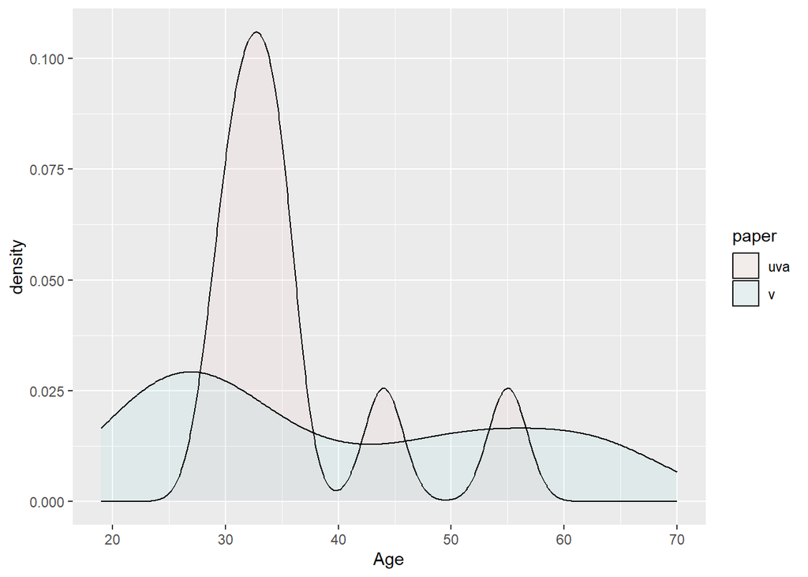

```r
allnorms %>%
  ggplot(aes(Age, fill = paper)) +geom_density(alpha = 0.05)
```

```r
wilcox.test(Age~paper, data = allnorms)
```

```
##
##  Wilcoxon rank sum test with continuity correction
##
## data:  Age by paper
## W = 446.5, p-value = 0.9956
## alternative hypothesis: true location shift is not equal to 0
```

```r
#making table of p values for wilcox

resultswcx <- tidy(wilcox.test(Age~paper, data = allnorms)) %>%
  mutate(var = "Normals Age Difference")
```

> compare uva RA to valori and uva normals combined

make a plot to see age difference between normals vs RA uva

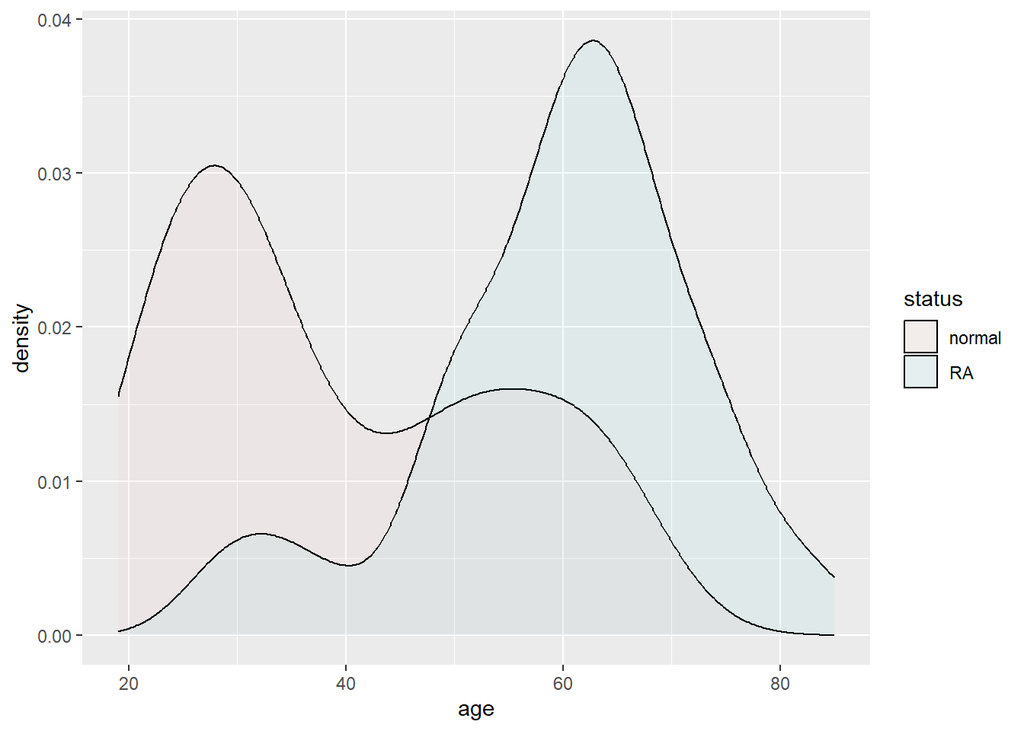

```r
alldat %>%
  ggplot(aes(age, fill = status)) +geom_density(alpha = 0.05)
```

```r
wilcox.test(age~status, data = alldat)
```

```
##
##  Wilcoxon rank sum test with continuity correction
##
## data:  age by status
## W = 1700.5, p-value < 2.2e-16
## alternative hypothesis: true location shift is not equal to 0
```

```r
#making table of p values for wilcox

#resultswcx <- tidy(wilcox.test(age~status, data = alldat)) %>%
  #mutate(var = "Normals vs RA Age Difference")
```

###Determining best method for comparing normals and RA

#### Explain VAF for each muation using RA status and age

> (mod3 from game plan)

make a box plot added constant that was half of smallest value before log transform

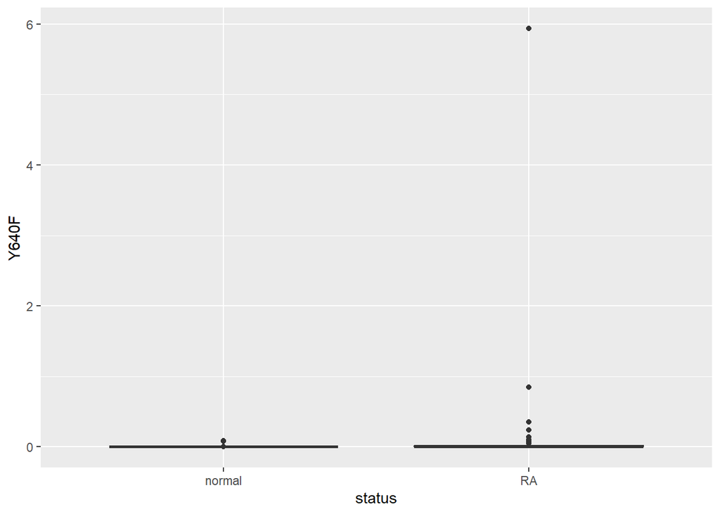

```r
alldat %>%
  ggplot(aes(status, Y640F)) + geom_boxplot()
```

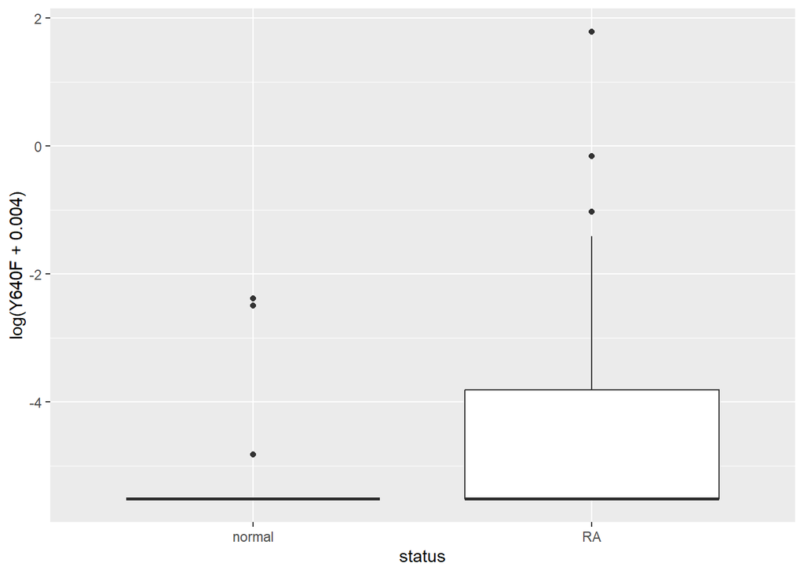

```r
alldat %>%
  ggplot(aes(status, log(Y640F+0.004))) + geom_boxplot()
```

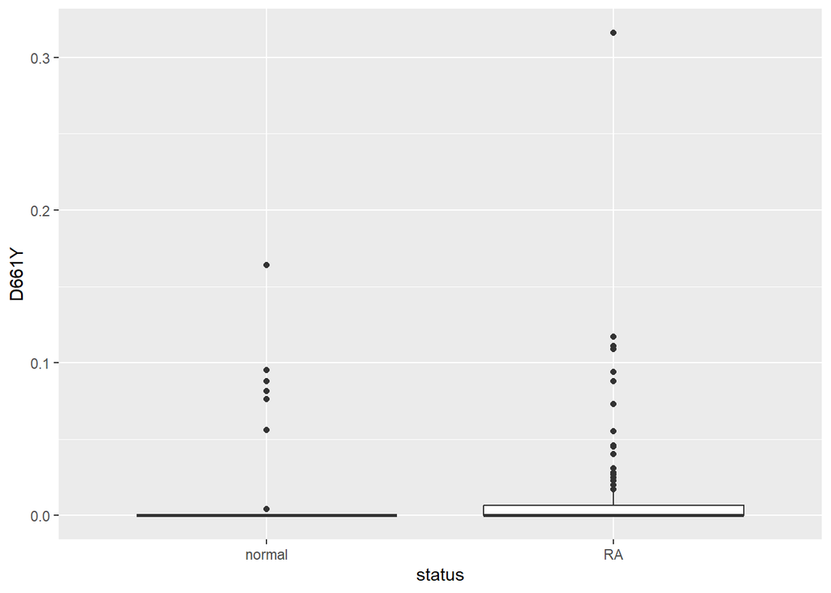

```r
alldat %>%
  ggplot(aes(status, D661Y)) + geom_boxplot()
```

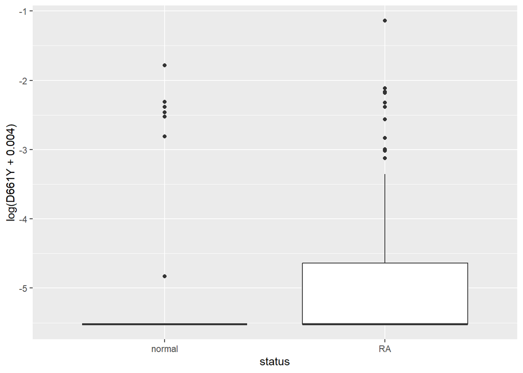

```r
alldat %>%
  ggplot(aes(status, log(D661Y+0.004))) + geom_boxplot()
```

make scatter plot showing age on x, vaf on y colored by RA status

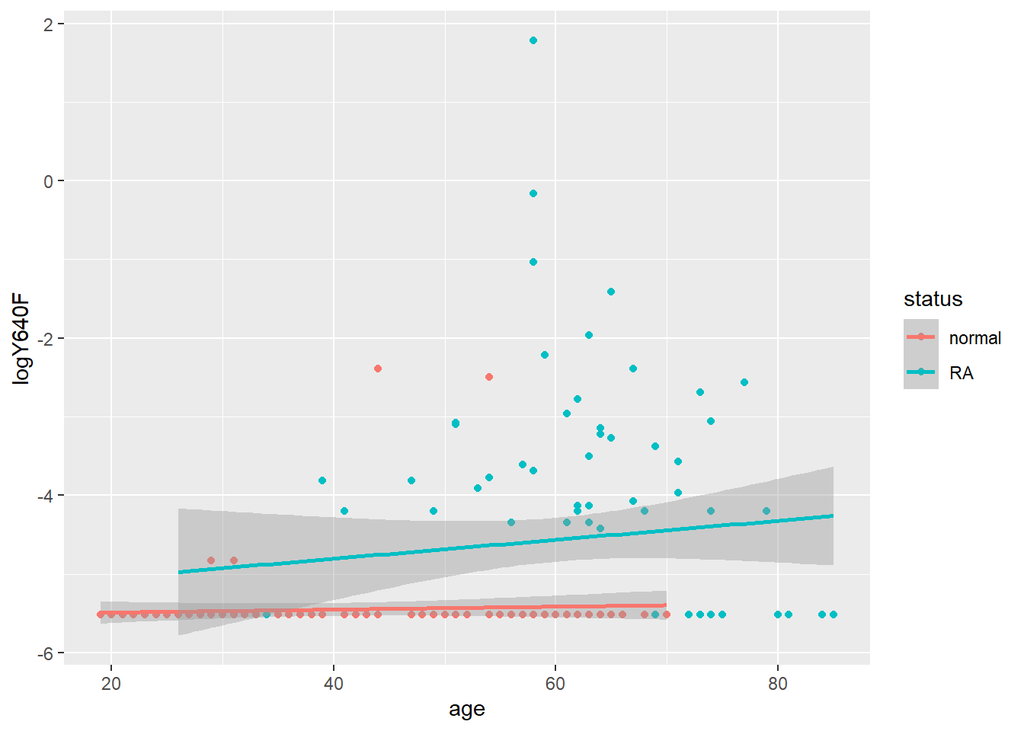

```r
alldat %>%
  ggplot(aes(age, logY640F, color = status)) + geom_point() +geom_smooth(method = "lm")
```

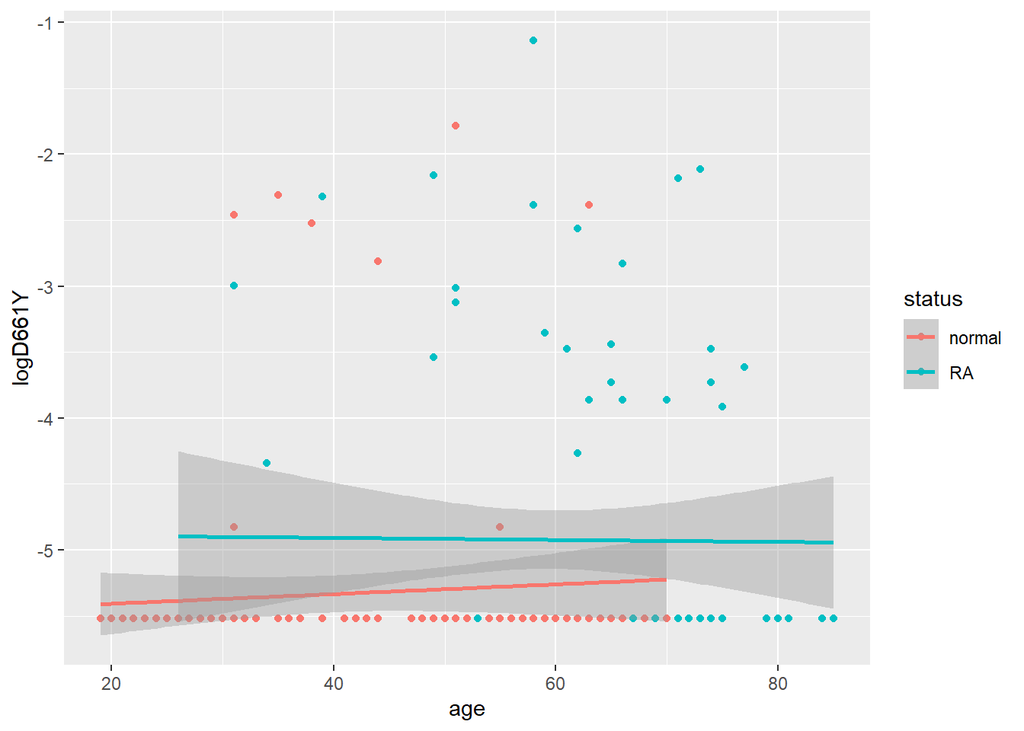

```r
alldat %>%
  ggplot(aes(age, logD661Y, color = status)) + geom_point() +geom_smooth(method = "lm")
```

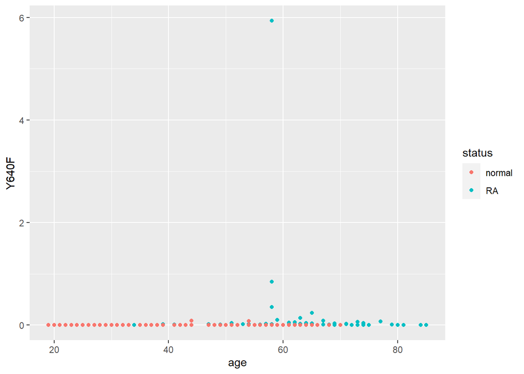

```r
alldat %>%
  ggplot(aes(age, Y640F, color = status)) + geom_point()
```

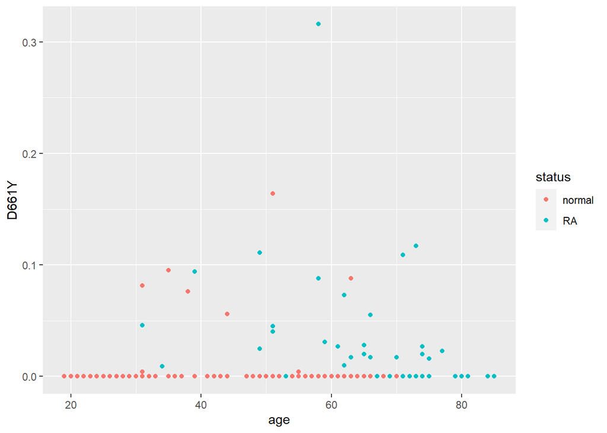

```r
alldat %>%
  ggplot(aes(age, D661Y, color = status)) + geom_point()
```

make linear models with VAF factoring in age

```r
mod3y <-lm(logY640F ~ status * age, data = alldat)
mod3d <-lm(logD661Y ~ status * age, data = alldat)
```

```r
mod3yb <-lm(logY640F ~ status + age, data = alldat)
mod3db <-lm(logD661Y ~ status + age, data = alldat)
```

test if mods are different >a non-significant p value in either of these anovas tells us that the model without the interaction (mod3yb and mod3b) fit just as well as the models with the interaction, so prefer the smaller model (mod3yb and mod3db)

```r
anova(mod3y,mod3yb)
```

```
## Analysis of Variance Table
##
## Model 1: logY640F ~ status * age
## Model 2: logY640F ~ status + age
##   Res.Df    RSS Df Sum of Sq     F Pr(>F)
## 1    202 204.51
## 2    203 205.46 -1  -0.95669 0.945 0.3322
```

```r
anova(mod3d,mod3db)
```

```
## Analysis of Variance Table
##
## Model 1: logD661Y ~ status * age
## Model 2: logD661Y ~ status + age
##   Res.Df    RSS Df Sum of Sq      F Pr(>F)
## 1    202 174.37
## 2    203 174.55 -1  -0.17987 0.2084 0.6485
```

interpretation of models

```r
summary(mod3yb)
```

```
##
## Call:
## lm(formula = logY640F ~ status + age, data = alldat)
##
## Residuals:
##     Min      1Q  Median      3Q     Max
## -1.1025 -0.8018 -0.0635  0.0367  6.3577
##
## Coefficients:
##              Estimate Std. Error t value Pr(>|t|)
## (Intercept) -5.681650   0.224245 -25.337  < 2e-16 ***
## statusRA     0.768830   0.174283   4.411 1.67e-05 ***
## age          0.005810   0.005109   1.137    0.257
## ---
## Signif. codes:  0 '***' 0.001 '**' 0.01 '*' 0.05 '.' 0.1 ' ' 1
##
## Residual standard error: 1.006 on 203 degrees of freedom
## Multiple R-squared:  0.1686, Adjusted R-squared:  0.1604
## F-statistic: 20.59 on 2 and 203 DF,  p-value: 7.241e-09
```

```r
summary(mod3db)
```

```
##
## Call:
## lm(formula = logD661Y ~ status + age, data = alldat)
##
## Residuals:
##     Min      1Q  Median      3Q     Max
## -0.6483 -0.5900 -0.2076 -0.1590  3.7862
##
## Coefficients:
##              Estimate Std. Error t value Pr(>|t|)
## (Intercept) -5.411089   0.206689 -26.180   <2e-16 ***
## statusRA     0.372635   0.160639   2.320   0.0214 *
## age          0.001945   0.004709   0.413   0.6800
## ---
## Signif. codes:  0 '***' 0.001 '**' 0.01 '*' 0.05 '.' 0.1 ' ' 1
##
## Residual standard error: 0.9273 on 203 degrees of freedom
## Multiple R-squared:  0.04834,    Adjusted R-squared:  0.03897
## F-statistic: 5.156 on 2 and 203 DF,  p-value: 0.006544
```

show this model in a plot

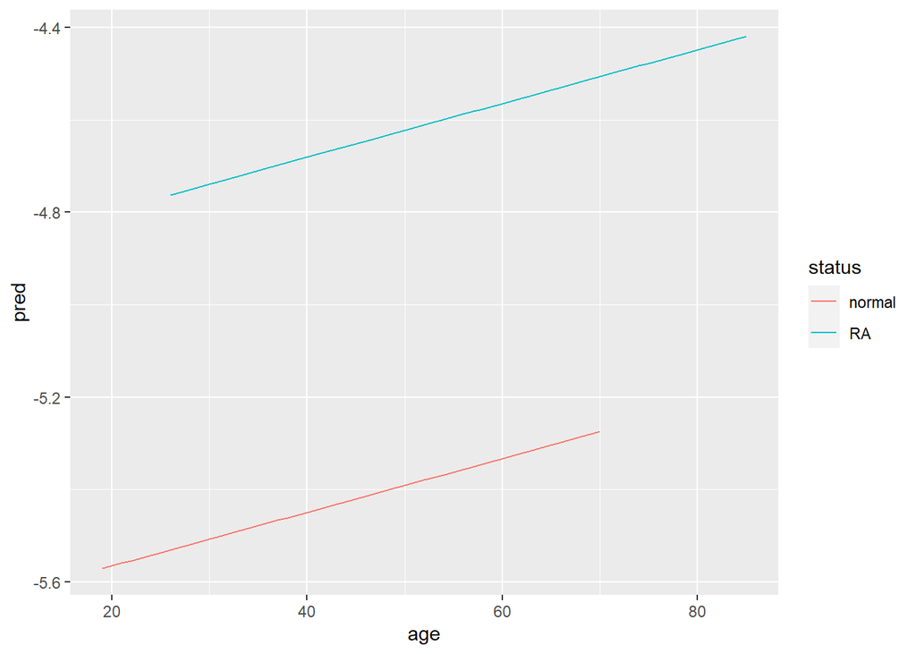

```r
alldat %>%
  add_predictions(mod3yb) %>%
  ggplot(aes(age, pred, color = status))+ geom_line()
```

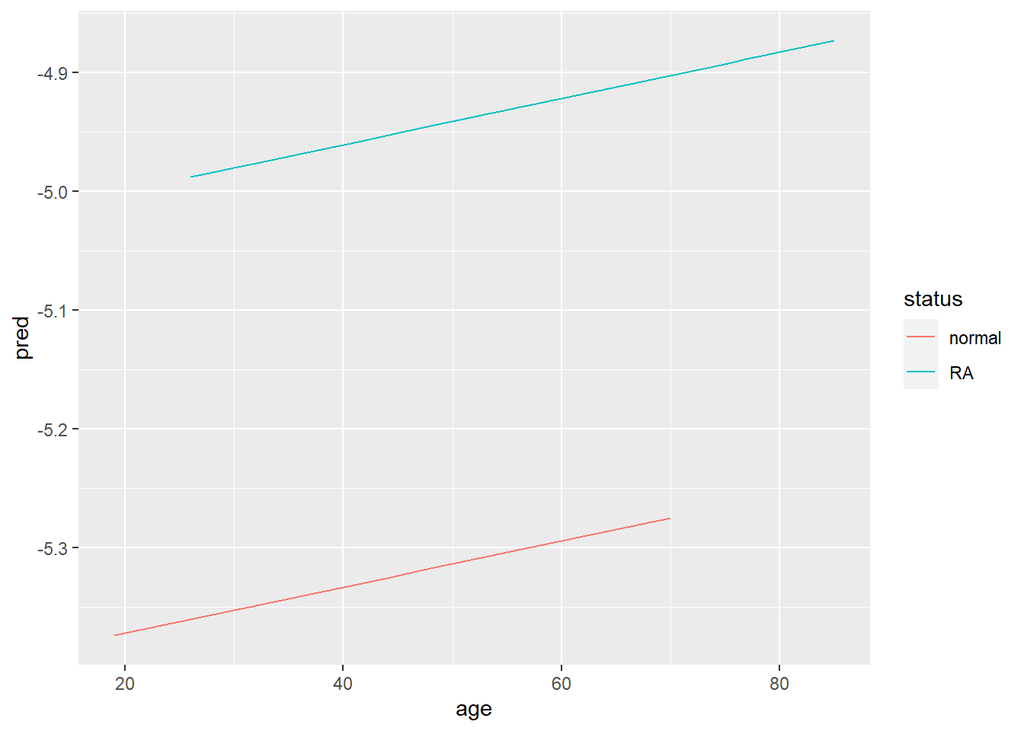

```r
alldat %>%
  add_predictions(mod3db) %>%
  ggplot(aes(age, pred, color = status))+ geom_line()
```

```r
summary(mod3y)
```

```
##
## Call:
## lm(formula = logY640F ~ status * age, data = alldat)
##
## Residuals:
##     Min      1Q  Median      3Q     Max
## -1.2596 -0.6361 -0.0678 -0.0358  6.3690
##
## Coefficients:
##               Estimate Std. Error t value Pr(>|t|)
## (Intercept)  -5.525097   0.276108 -20.011   <2e-16 ***
## statusRA      0.239069   0.572166   0.418    0.677
## age           0.001856   0.006531   0.284    0.777
## statusRA:age  0.010193   0.010486   0.972    0.332
## ---
## Signif. codes:  0 '***' 0.001 '**' 0.01 '*' 0.05 '.' 0.1 ' ' 1
##
## Residual standard error: 1.006 on 202 degrees of freedom
## Multiple R-squared:  0.1725, Adjusted R-squared:  0.1602
## F-statistic: 14.04 on 3 and 202 DF,  p-value: 2.397e-08
```

```r
summary(mod3d)
```

```
##
## Call:
## lm(formula = logD661Y ~ status * age, data = alldat)
##
## Residuals:
##     Min      1Q  Median      3Q     Max
## -0.6251 -0.5947 -0.2255 -0.1340  3.7813
##
## Coefficients:
##               Estimate Std. Error t value Pr(>|t|)
## (Intercept)  -5.478970   0.254955 -21.490   <2e-16 ***
## statusRA      0.602340   0.528333   1.140    0.256
## age           0.003660   0.006031   0.607    0.545
## statusRA:age -0.004420   0.009683  -0.456    0.649
## ---
## Signif. codes:  0 '***' 0.001 '**' 0.01 '*' 0.05 '.' 0.1 ' ' 1
##
## Residual standard error: 0.9291 on 202 degrees of freedom
## Multiple R-squared:  0.04932,    Adjusted R-squared:  0.0352
## F-statistic: 3.493 on 3 and 202 DF,  p-value: 0.01662
```

show this model in a plot

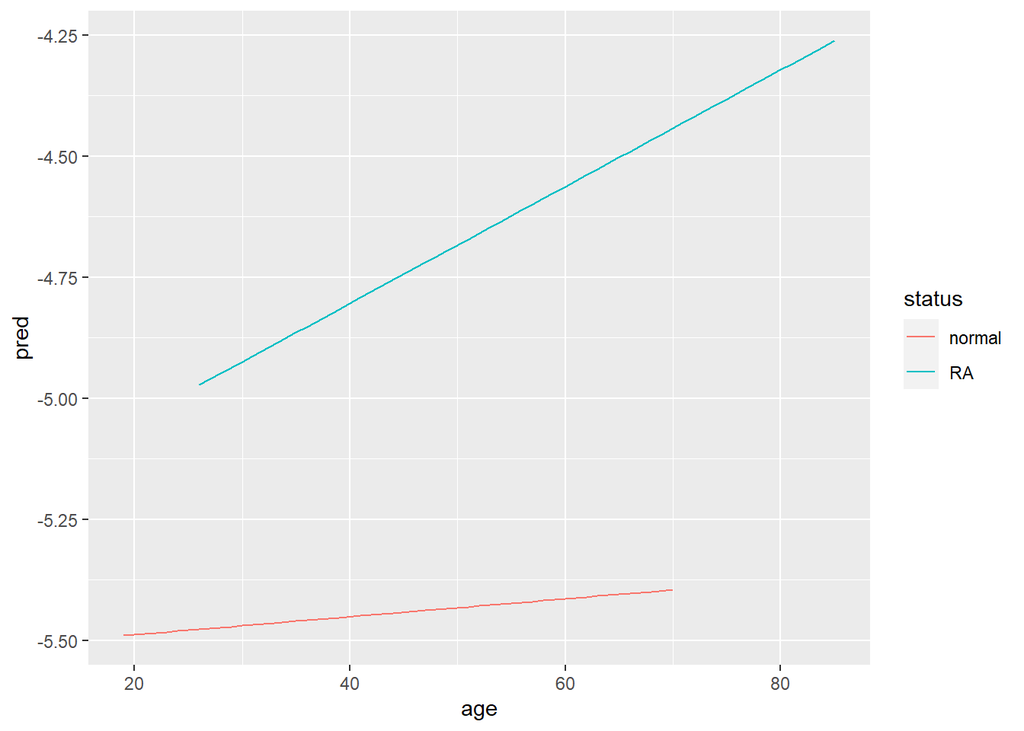

```r
alldat %>%
  add_predictions(mod3y) %>%
  ggplot(aes(age, pred, color = status))+ geom_line()
```

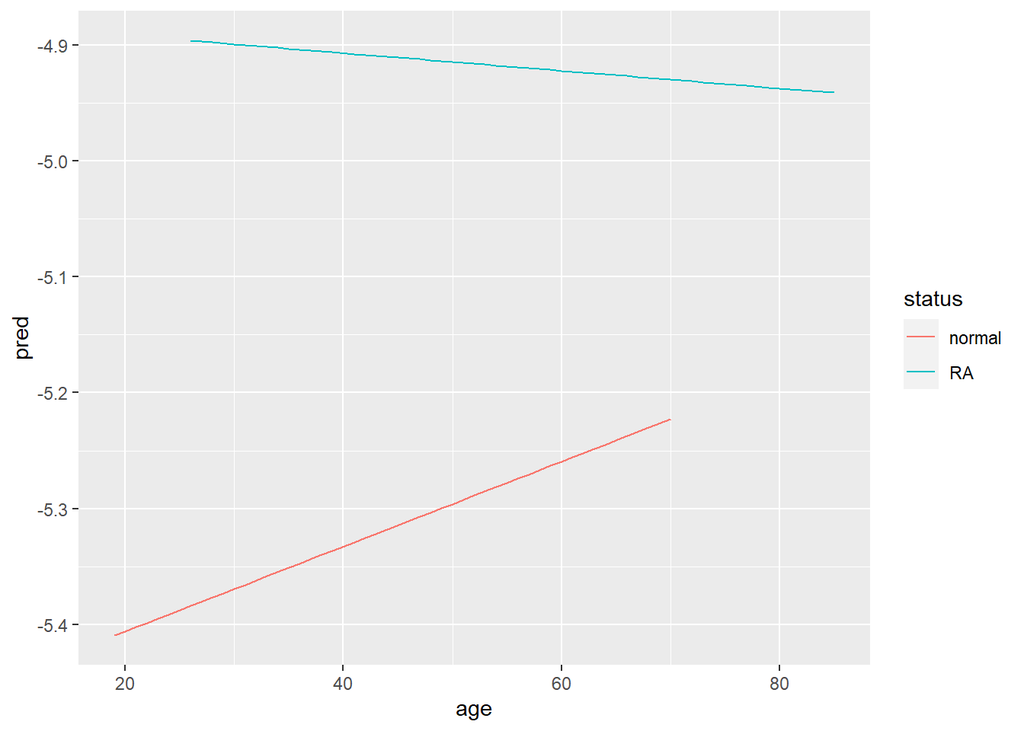

```r
alldat %>%
  add_predictions(mod3d) %>%
  ggplot(aes(age, pred, color = status))+ geom_line()
```

#### bin by age and look at VAFs

```r
agevafs <- alldat %>% select(age, logY640F, status) #pick the variable

#make bin labels
abinlabels <- c("<25","26-40", "41-55", "56-70", ">71")

#make table with bins
agebins <- as_tibble(agevafs) %>%
  mutate(tag = case_when(
    age <= 25 ~ abinlabels[1],
    age >= 26 & age <= 40 ~ abinlabels[2],
    age >= 41 & age <= 55 ~ abinlabels[3],
    age >= 56 & age <= 70 ~ abinlabels[4],
    age >= 71 ~ abinlabels[5]
    ))

summary(agebins)
```

```
##       age           logY640F         status              tag
##  Min.   :19.00   Min.   :-5.521   Length:206         Length:206
##  1st Qu.:32.00   1st Qu.:-5.521   Class :character   Class :character
##  Median :52.00   Median :-5.521   Mode  :character   Mode  :character
##  Mean   :49.21   Mean   :-5.030
##  3rd Qu.:63.00   3rd Qu.:-5.521
##  Max.   :85.00   Max.   : 1.782
```

```r
#make it a factor
agebins$tag <- factor(agebins$tag,
                       levels = abinlabels,
                       ordered = FALSE)
summary(agebins$tag)
```

```
##   <25 26-40 41-55 56-70   >71
##    22    50    43    74    17
```

try plotting

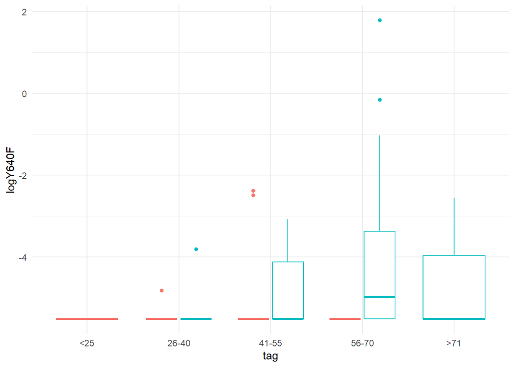

```r
 ggplot(data = agebins, mapping = aes(tag, logY640F, color = status)) +
   geom_boxplot() +
guides(color=FALSE)+
  theme_minimal()
```

#### bin by age and look at yes no mutation

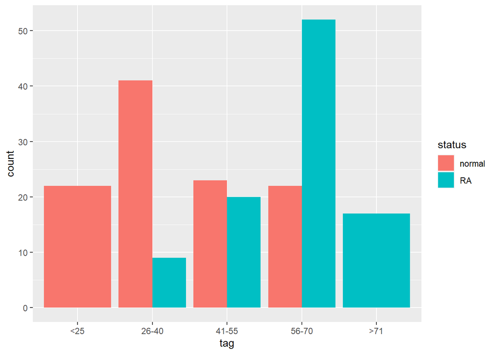

```r
ggplot(data = agebins, mapping = aes(tag, fill = status)) +
    geom_bar( position=position_dodge())
```

#### bin by VAF and look at status

```r
vafstat <- alldat %>% select(Y640F,status, age) #pick the variable

#make bin labels
binlabels <- c("0","[0.008-0.05]", ">0.05")

#make table with bins
yvafbins <- as_tibble(vafstat) %>%
  mutate(tag = case_when(
    Y640F < 0.008 ~ binlabels[1],
    Y640F >= 0.008 & Y640F < 0.05 ~ binlabels[2],
    Y640F >= 0.05 ~ binlabels[3]
    ))

summary(yvafbins)
```

```
##      Y640F           status               age            tag
##  Min.   :0.0000   Length:206         Min.   :19.00   Length:206
##  1st Qu.:0.0000   Class :character   1st Qu.:32.00   Class :character
##  Median :0.0000   Mode  :character   Median :52.00   Mode  :character
##  Mean   :0.0424                      Mean   :49.21
##  3rd Qu.:0.0000                      3rd Qu.:63.00
##  Max.   :5.9370                      Max.   :85.00
```

```r
#make it a factor
yvafbins$tag <- factor(yvafbins$tag,
                       levels = binlabels,
                       ordered = FALSE)
summary(yvafbins$tag)
```

```
##            0 [0.008-0.05]        >0.05
##          163           31           12
```

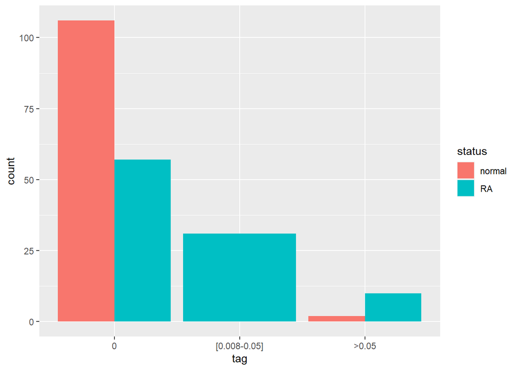

```r
yvafbins %>%
  ggplot(aes(tag, fill = status)) + geom_bar(position=position_dodge())
```

### making yes no bins for VAF

```r
alldat <- alldat %>%
  mutate(muty640f05 = if_else(Y640F >= 0.05, 1, 0),
         muty640f008 = if_else(Y640F >= 0.008, 1, 0),
         mutd661y05 = if_else(D661Y >= 0.05, 1, 0),
         mutd661y008 = if_else(D661Y >= 0.008, 1, 0))

alldat <- alldat %>%
  mutate(mutall008 = case_when(D661Y >= 0.008 & Y640F >= 0.008 ~ 1,
                             D661Y >= 0.008 ~ 1,
                             Y640F >= 0.008~ 1,
                             TRUE ~ 0))

alldat %>%
  count(status, muty640f05)
```

```
## # A tibble: 4 × 3
##   status muty640f05     n
##   <chr>       <dbl> <int>
## 1 RA              0    88
## 2 RA              1    10
## 3 normal          0   106
## 4 normal          1     2
```

```r
alldat %>%
  count(status, muty640f008)
```

```
## # A tibble: 4 × 3
##   status muty640f008     n
##   <chr>        <dbl> <int>
## 1 RA               0    57
## 2 RA               1    41
## 3 normal           0   106
## 4 normal           1     2
```

```r
mod83highy <- glm(muty640f05~status +age, data = alldat)

summary(mod83highy)
```

```
##
## Call:
## glm(formula = muty640f05 ~ status + age, data = alldat)
##
## Coefficients:
##              Estimate Std. Error t value Pr(>|t|)
## (Intercept) -0.043406   0.051526  -0.842    0.401
## statusRA     0.051892   0.040046   1.296    0.197
## age          0.001564   0.001174   1.332    0.184
##
## (Dispersion parameter for gaussian family taken to be 0.05343691)
##
##     Null deviance: 11.301  on 205  degrees of freedom
## Residual deviance: 10.848  on 203  degrees of freedom
## AIC: -13.846
##
## Number of Fisher Scoring iterations: 2
```

```r
mod83lowy <- glm(muty640f008~status +age, data = alldat)

summary(mod83lowy)
```

```
##
## Call:
## glm(formula = muty640f008 ~ status + age, data = alldat)
##
## Coefficients:
##              Estimate Std. Error t value Pr(>|t|)
## (Intercept) -0.079849   0.079109  -1.009    0.314
## statusRA     0.349603   0.061483   5.686 4.48e-08 ***
## age          0.002484   0.001802   1.379    0.170
## ---
## Signif. codes:  0 '***' 0.001 '**' 0.01 '*' 0.05 '.' 0.1 ' ' 1
##
## (Dispersion parameter for gaussian family taken to be 0.1259632)
##
##     Null deviance: 34.024  on 205  degrees of freedom
## Residual deviance: 25.571  on 203  degrees of freedom
## AIC: 162.8
##
## Number of Fisher Scoring iterations: 2
```

```r
mod83highd <- glm(mutd661y05~status +age, data = alldat)

summary(mod83highd)
```

```
##
## Call:
## glm(formula = mutd661y05 ~ status + age, data = alldat)
##
## Coefficients:
##              Estimate Std. Error t value Pr(>|t|)
## (Intercept) 0.0331818  0.0564088   0.588    0.557
## statusRA    0.0146487  0.0438409   0.334    0.739
## age         0.0005651  0.0012851   0.440    0.661
##
## (Dispersion parameter for gaussian family taken to be 0.06404543)
##
##     Null deviance: 13.049  on 205  degrees of freedom
## Residual deviance: 13.001  on 203  degrees of freedom
## AIC: 23.459
##
## Number of Fisher Scoring iterations: 2
```

```r
mod83lowd <- glm(mutd661y008~status +age, data = alldat)

summary(mod83lowd)
```

```
##
## Call:
## glm(formula = mutd661y008 ~ status + age, data = alldat)
##
## Coefficients:
##              Estimate Std. Error t value Pr(>|t|)
## (Intercept) 0.0228469  0.0770591   0.296  0.76716
## statusRA    0.1828391  0.0598903   3.053  0.00257 **
## age         0.0008261  0.0017556   0.471  0.63845
## ---
## Signif. codes:  0 '***' 0.001 '**' 0.01 '*' 0.05 '.' 0.1 ' ' 1
##
## (Dispersion parameter for gaussian family taken to be 0.1195204)
##
##     Null deviance: 26.335  on 205  degrees of freedom
## Residual deviance: 24.263  on 203  degrees of freedom
## AIC: 151.98
##
## Number of Fisher Scoring iterations: 2
```

### Running logistic regression with yes no bins

Explaining whether or not someone has >0.05 level (or >0.008 level) of mutation using status and age

```r
mod83highy <- glm(muty640f05 ~ status + age, data = alldat, family = binomial)
summary(mod83highy)
```

```
##
## Call:
## glm(formula = muty640f05 ~ status + age, family = binomial, data = alldat)
##
## Coefficients:
##             Estimate Std. Error z value Pr(>|z|)
## (Intercept) -5.56814    1.43235  -3.887 0.000101 ***
## statusRA     1.12648    0.89508   1.259 0.208205
## age          0.03663    0.02602   1.407 0.159291
## ---
## Signif. codes:  0 '***' 0.001 '**' 0.01 '*' 0.05 '.' 0.1 ' ' 1
##
## (Dispersion parameter for binomial family taken to be 1)
##
##     Null deviance: 91.518  on 205  degrees of freedom
## Residual deviance: 82.363  on 203  degrees of freedom
## AIC: 88.363
##
## Number of Fisher Scoring iterations: 6
```

```r
mod83lowy <- glm(muty640f008~status + age, data = alldat, family = binomial)
summary(mod83lowy)
```

```
##
## Call:
## glm(formula = muty640f008 ~ status + age, family = binomial,
##     data = alldat)
##
## Coefficients:
##             Estimate Std. Error z value Pr(>|z|)
## (Intercept) -4.99663    1.02433  -4.878 1.07e-06 ***
## statusRA     3.20559    0.78630   4.077 4.57e-05 ***
## age          0.02429    0.01632   1.488    0.137
## ---
## Signif. codes:  0 '***' 0.001 '**' 0.01 '*' 0.05 '.' 0.1 ' ' 1
##
## (Dispersion parameter for binomial family taken to be 1)
##
##     Null deviance: 211.06  on 205  degrees of freedom
## Residual deviance: 150.84  on 203  degrees of freedom
## AIC: 156.84
##
## Number of Fisher Scoring iterations: 6
```

```r
mod83highd <- glm(mutd661y05~status +age, data = alldat, family = binomial)
summary(mod83highd)
```

```
##
## Call:
## glm(formula = mutd661y05 ~ status + age, family = binomial, data = alldat)
##
## Coefficients:
##              Estimate Std. Error z value Pr(>|z|)
## (Intercept) -3.208667   0.952433  -3.369 0.000755 ***
## statusRA     0.228498   0.689371   0.331 0.740299
## age          0.009268   0.020625   0.449 0.653176
## ---
## Signif. codes:  0 '***' 0.001 '**' 0.01 '*' 0.05 '.' 0.1 ' ' 1
##
## (Dispersion parameter for binomial family taken to be 1)
##
##     Null deviance: 102.31  on 205  degrees of freedom
## Residual deviance: 101.56  on 203  degrees of freedom
## AIC: 107.56
##
## Number of Fisher Scoring iterations: 5
```

```r
mod83lowd <- glm(mutd661y008~status +age, data = alldat, family = binomial)
summary(mod83lowd)
```

```
##
## Call:
## glm(formula = mutd661y008 ~ status + age, family = binomial,
##     data = alldat)
##
## Coefficients:
##              Estimate Std. Error z value Pr(>|z|)
## (Intercept) -3.150413   0.771741  -4.082 4.46e-05 ***
## statusRA     1.606494   0.567555   2.831  0.00465 **
## age          0.007857   0.015729   0.500  0.61738
## ---
## Signif. codes:  0 '***' 0.001 '**' 0.01 '*' 0.05 '.' 0.1 ' ' 1
##
## (Dispersion parameter for binomial family taken to be 1)
##
##     Null deviance: 174.5  on 205  degrees of freedom
## Residual deviance: 157.4  on 203  degrees of freedom
## AIC: 163.4
##
## Number of Fisher Scoring iterations: 5
```

```r
mod83lowall <- glm(mutall008~status +age, data = alldat, family = binomial)
summary(mod83lowall)
```

```
##
## Call:
## glm(formula = mutall008 ~ status + age, family = binomial, data = alldat)
##
## Coefficients:
##             Estimate Std. Error z value Pr(>|z|)
## (Intercept) -3.36420    0.70152  -4.796 1.62e-06 ***
## statusRA     2.28000    0.47689   4.781 1.74e-06 ***
## age          0.02019    0.01373   1.471    0.141
## ---
## Signif. codes:  0 '***' 0.001 '**' 0.01 '*' 0.05 '.' 0.1 ' ' 1
##
## (Dispersion parameter for binomial family taken to be 1)
##
##     Null deviance: 248.55  on 205  degrees of freedom
## Residual deviance: 190.33  on 203  degrees of freedom
## AIC: 196.33
##
## Number of Fisher Scoring iterations: 5
```

#### Results from logsitic regression for Manuscript

#####All muts >0.008 Using the model with the 0.008 threshold, here is the interpretation of the model and a plot for the manuscript

```r
summary(mod83lowall)
```

```
##
## Call:
## glm(formula = mutall008 ~ status + age, family = binomial, data = alldat)
##
## Coefficients:
##             Estimate Std. Error z value Pr(>|z|)
## (Intercept) -3.36420    0.70152  -4.796 1.62e-06 ***
## statusRA     2.28000    0.47689   4.781 1.74e-06 ***
## age          0.02019    0.01373   1.471    0.141
## ---
## Signif. codes:  0 '***' 0.001 '**' 0.01 '*' 0.05 '.' 0.1 ' ' 1
##
## (Dispersion parameter for binomial family taken to be 1)
##
##     Null deviance: 248.55  on 205  degrees of freedom
## Residual deviance: 190.33  on 203  degrees of freedom
## AIC: 196.33
##
## Number of Fisher Scoring iterations: 5
```

Interpretation: - This model assumes the same effect of age for both RA and normals (no interaction term)

To get predicted probabilities at given ages for each status, use `ggeffect()`

```r
ggeffect(mod83lowall, terms = c("age[20,50]", "status"))
```

```
## # Predicted probabilities of mutall008
##
## # status = normal
##
## age | Predicted |       95% CI
## ------------------------------
##  20 |      0.05 | [0.02, 0.12]
##  50 |      0.09 | [0.04, 0.17]
##
## # status = RA
##
## age | Predicted |       95% CI
## ------------------------------
##  20 |      0.34 | [0.14, 0.61]
##  50 |      0.48 | [0.37, 0.60]
```

Plot

```r
#retrieve average effect of status
ggeffect(mod83lowall, terms = c("status"))
```

```
## # Predicted probabilities of mutall008
##
## status | Predicted |       95% CI
## ---------------------------------
## normal |      0.09 | [0.04, 0.16]
## RA     |      0.48 | [0.36, 0.60]
```

```r
#retrieve average age
summary(alldat$age)
```

```
##    Min. 1st Qu.  Median    Mean 3rd Qu.    Max.
##   19.00   32.00   52.00   49.21   63.00   85.00
```

```r
ggeffect(mod83lowall, terms = c("age[20,49.21]","status"))
```

```
## # Predicted probabilities of mutall008
##
## # status = normal
##
##   age | Predicted |       95% CI
## --------------------------------
## 20.00 |      0.05 | [0.02, 0.12]
## 49.21 |      0.09 | [0.04, 0.16]
##
## # status = RA
##
##   age | Predicted |       95% CI
## --------------------------------
## 20.00 |      0.34 | [0.14, 0.61]
## 49.21 |      0.48 | [0.36, 0.60]
```

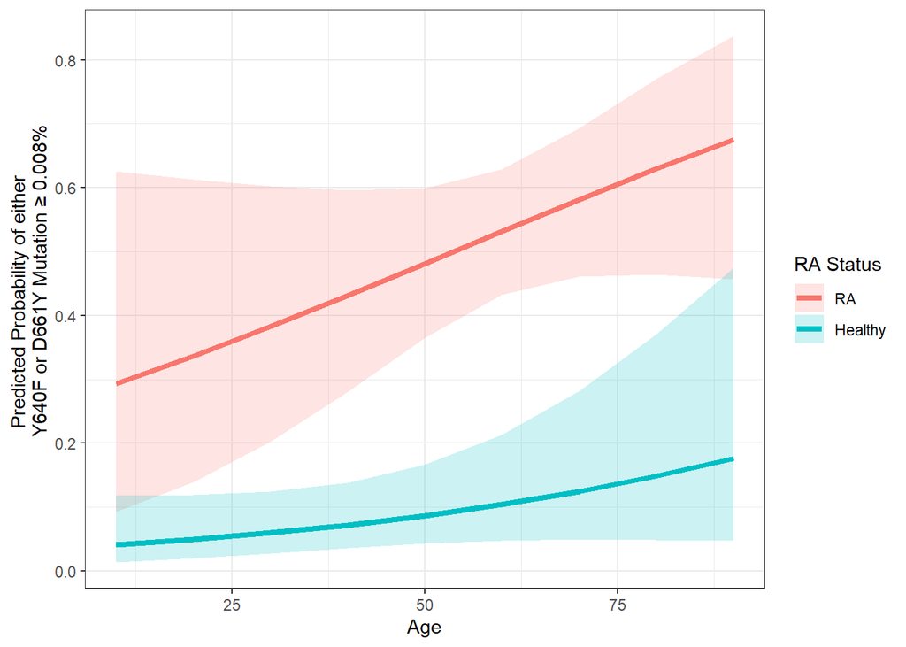

```r
ggeffect(mod83lowall, terms = c("age", "status")) %>%
  as_tibble() %>%
  rename(age = x,
         status = group) %>%
  mutate(status = factor(status,
                         levels = c("RA", "normal"),
                         labels = c("RA", "Healthy"))) %>%
  ggplot(aes(age, predicted)) +
  geom_line(aes(color = status),
            linewidth = 1.5) +
  geom_ribbon(aes(ymin = conf.low,
                  ymax = conf.high,
                  fill = status),
              alpha = .2) +
  #geom_point(aes(x=49.21, y=0.09), size = 2)+
  labs(y = "Predicted Probability of either
       Y640F or D661Y Mutation \u2265 0.008%",
       x = "Age",
       color = "RA Status",
       fill = "RA Status") +
  theme_bw()
```

#####Y640F Using the model with the 0.008 threshold, here is the interpretation of the model and a plot for the manuscript

```r
summary(mod83lowy)
```

```
##
## Call:
## glm(formula = muty640f008 ~ status + age, family = binomial,
##     data = alldat)
##
## Coefficients:
##             Estimate Std. Error z value Pr(>|z|)
## (Intercept) -4.99663    1.02433  -4.878 1.07e-06 ***
## statusRA     3.20559    0.78630   4.077 4.57e-05 ***
## age          0.02429    0.01632   1.488    0.137
## ---
## Signif. codes:  0 '***' 0.001 '**' 0.01 '*' 0.05 '.' 0.1 ' ' 1
##
## (Dispersion parameter for binomial family taken to be 1)
##
##     Null deviance: 211.06  on 205  degrees of freedom
## Residual deviance: 150.84  on 203  degrees of freedom
## AIC: 156.84
##
## Number of Fisher Scoring iterations: 6
```

Interpretation: - This model assumes the same effect of age for both RA and normals (no interaction term)

To get predicted probabilities at given ages for each status, use `ggeffect()`

```r
ggeffect(mod83lowy, terms = c("age[20,50]", "status"))
```

```
## # Predicted probabilities of muty640f008
##
## # status = normal
##
## age | Predicted |       95% CI
## ------------------------------
##  20 |      0.01 | [0.00, 0.05]
##  50 |      0.02 | [0.01, 0.09]
##
## # status = RA
##
## age | Predicted |       95% CI
## ------------------------------
##  20 |      0.21 | [0.07, 0.51]
##  50 |      0.36 | [0.25, 0.49]
```

Plot

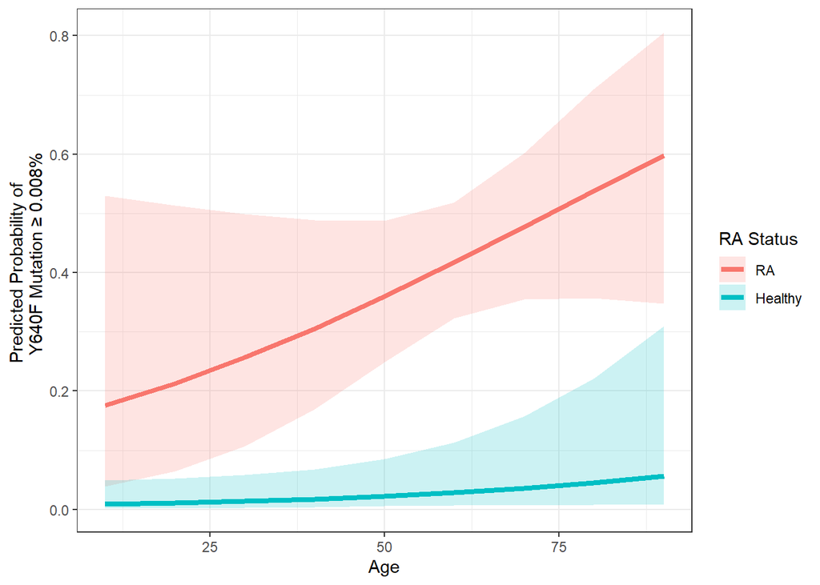

```r
ggeffect(mod83lowy, terms = c("age", "status")) %>%
  as_tibble() %>%
  rename(age = x,
         status = group) %>%
  mutate(status = factor(status,
                         levels = c("RA", "normal"),
                         labels = c("RA", "Healthy"))) %>%
  ggplot(aes(age, predicted)) +
  geom_line(aes(color = status),
            linewidth = 1.5) +
  geom_ribbon(aes(ymin = conf.low,
                  ymax = conf.high,
                  fill = status),
              alpha = .2) +
  labs(y = "Predicted Probability of
       Y640F Mutation \u2265 0.008%",
       x = "Age",
       color = "RA Status",
       fill = "RA Status") +
  theme_bw()
```

#####D661Y **D661Y** Using the model with the 0.008 threshold, here is the interpretation of the model and a plot for the manuscript

```r
summary(mod83lowd)
```

```
##
## Call:
## glm(formula = mutd661y008 ~ status + age, family = binomial,
##     data = alldat)
##
## Coefficients:
##              Estimate Std. Error z value Pr(>|z|)
## (Intercept) -3.150413   0.771741  -4.082 4.46e-05 ***
## statusRA     1.606494   0.567555   2.831  0.00465 **
## age          0.007857   0.015729   0.500  0.61738
## ---
## Signif. codes:  0 '***' 0.001 '**' 0.01 '*' 0.05 '.' 0.1 ' ' 1
##
## (Dispersion parameter for binomial family taken to be 1)
##
##     Null deviance: 174.5  on 205  degrees of freedom
## Residual deviance: 157.4  on 203  degrees of freedom
## AIC: 163.4
##
## Number of Fisher Scoring iterations: 5
```

Interpretation: - This model assumes the same effect of age for both RA and normals (no interaction term)

To get predicted probabilities at given ages for each status, use `ggeffect()`

```r
ggeffect(mod83lowd, terms = c("age[20,50]", "status"))
```

```
## # Predicted probabilities of mutd661y008
##
## # status = normal
##
## age | Predicted |       95% CI
## ------------------------------
##  20 |      0.05 | [0.02, 0.13]
##  50 |      0.06 | [0.03, 0.13]
##
## # status = RA
##
## age | Predicted |       95% CI
## ------------------------------
##  20 |      0.20 | [0.06, 0.48]
##  50 |      0.24 | [0.15, 0.36]
```

Plot

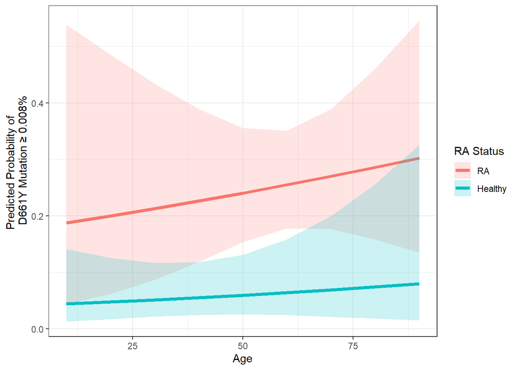

```r
ggeffect(mod83lowd, terms = c("age", "status")) %>%
  as_tibble() %>%
  rename(age = x,
         status = group) %>%
  mutate(status = factor(status,
                         levels = c("RA", "normal"),
                         labels = c("RA", "Healthy"))) %>%
  ggplot(aes(age, predicted)) +
  geom_line(aes(color = status),
            linewidth = 1.5) +
  geom_ribbon(aes(ymin = conf.low,
                  ymax = conf.high,
                  fill = status),
              alpha = .2) +
  labs(y = "Predicted Probability of
       D661Y Mutation \u2265 0.008%",
       x = "Age",
       color = "RA Status",
       fill = "RA Status") +
  theme_bw()
```

# T TEST by Mutation Y/N

T-test Assumption Flow chart: - Random Sampling – if not met, no basic statistics are appropriate - Independent Samples – if not met, paired t-test - Normality – if not met, Wilcoxon-Mann-Whitney U test - Equal variance – if not met, Welch’s t-test - If equal variance and normality are not met, choose which assumption is worse. Wilcox test assumes equal variance

Density plots are not the best option to assess normality, qqplots are better

Check the number of WT and Mut

```r
RA %>%
  count(Mutation)
```

```
## # A tibble: 2 × 2
##   Mutation     n
##   <chr>    <int>
## 1 n           82
## 2 y           16
```

### Age T Test by Mutation

> used welch’s t test because normality was fine, equal variance was not

make a plot

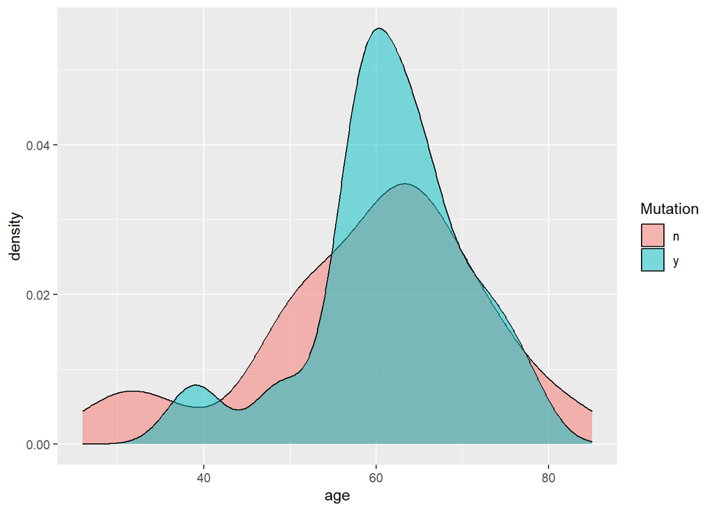

```r
RA %>%
  ggplot(aes(age, fill = Mutation))+geom_density(alpha = 0.5)
```

normality looks fine, but equal variance may not be met

```r
t.test(age~Mutation, data = RA)
```

```
##
##  Welch Two Sample t-test
##
## data:  age by Mutation
## t = -0.77453, df = 28.496, p-value = 0.445
## alternative hypothesis: true difference in means between group n and group y is not equal to 0
## 95 percent confidence interval:
##  -7.601804  3.428023
## sample estimates:
## mean in group n mean in group y
##        59.47561        61.56250
```

```r
t.test(age~lowvafmut, data = RA)
```

```
##
##  Welch Two Sample t-test
##
## data:  age by lowvafmut
## t = -1.0464, df = 81.527, p-value = 0.2985
## alternative hypothesis: true difference in means between group n and group y is not equal to 0
## 95 percent confidence interval:
##  -7.791849  2.420612
## sample estimates:
## mean in group n mean in group y
##        58.39130        61.07692
```

```r
t.test(age~ymut, data = RA)
```

```
##
##  Welch Two Sample t-test
##
## data:  age by ymut
## t = -1.3765, df = 94.189, p-value = 0.1719
## alternative hypothesis: true difference in means between group n and group y is not equal to 0
## 95 percent confidence interval:
##  -7.940574  1.438221
## sample estimates:
## mean in group n mean in group y
##        58.45614        61.70732
```

```r
t.test(age~dmut, data = RA)
```

```
##
##  Welch Two Sample t-test
##
## data:  age by dmut
## t = -0.13998, df = 41.329, p-value = 0.8894
## alternative hypothesis: true difference in means between group n and group y is not equal to 0
## 95 percent confidence interval:
##  -6.287784  5.472442
## sample estimates:
## mean in group n mean in group y
##        59.71233        60.12000
```

```r
#turning this into a dataset

resultst <- tidy(t.test(age~Mutation, data = RA)) %>%
  mutate(var = "age")

resultstlow <- tidy(t.test(age~lowvafmut, data = RA)) %>%
  mutate(var = "age")

resultsty <- tidy(t.test(age~ymut, data = RA)) %>%
  mutate(var = "age")

resultstd <- tidy(t.test(age~dmut, data = RA)) %>%
  mutate(var = "age")
```

### SJ T Test by Mutation

> Notes: couldn’t log transform because lots of zeros, ran wilcox on raw, saw no difference

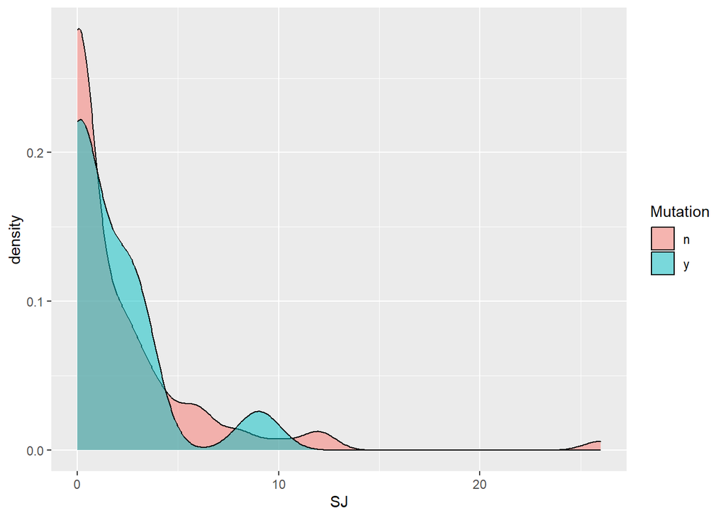

```r
RA %>%
  ggplot(aes(SJ, fill = Mutation))+geom_density(alpha = 0.5)
```

```r
#look up zeros
RA %>%
  arrange(SJ) %>%
  select(Mutation, SJ)
```

```
## # A tibble: 98 × 2
##    Mutation    SJ
##    <chr>    <dbl>
##  1 n            0
##  2 n            0
##  3 n            0
##  4 n            0
##  5 n            0
##  6 n            0
##  7 n            0
##  8 n            0
##  9 n            0
## 10 n            0
## # ℹ 88 more rows
```

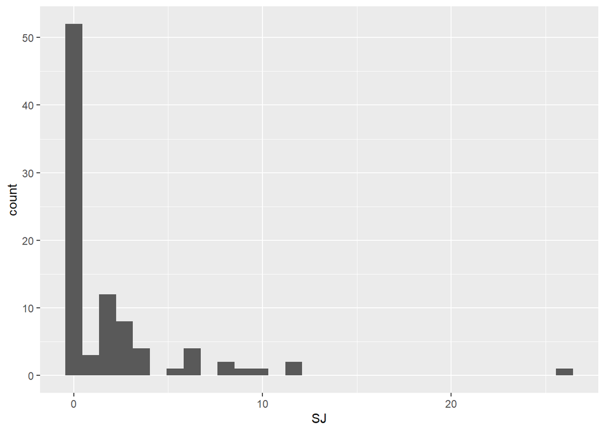

```r
#data does have lots of zeros, log transform didn't help, should use wilcox
RA %>%
  ggplot(aes(SJ))+geom_histogram()
```

Run Wilcox

```r
wilcox.test(SJ~Mutation, data = RA)
```

```
##
##  Wilcoxon rank sum test with continuity correction
##
## data:  SJ by Mutation
## W = 546.5, p-value = 0.9318
## alternative hypothesis: true location shift is not equal to 0
```

```r
wilcox.test(SJ~lowvafmut, data = RA)
```

```
##
##  Wilcoxon rank sum test with continuity correction
##
## data:  SJ by lowvafmut
## W = 1100.5, p-value = 0.5482
## alternative hypothesis: true location shift is not equal to 0
```

```r
wilcox.test(SJ~ymut, data = RA)
```

```
##
##  Wilcoxon rank sum test with continuity correction
##
## data:  SJ by ymut
## W = 1115, p-value = 0.3365
## alternative hypothesis: true location shift is not equal to 0
```

```r
wilcox.test(SJ~dmut, data = RA)
```

```
##
##  Wilcoxon rank sum test with continuity correction
##
## data:  SJ by dmut
## W = 777.5, p-value = 0.8529
## alternative hypothesis: true location shift is not equal to 0
```

```r
#making table of p values for wilcox

resultswcx <- tidy(wilcox.test(SJ~Mutation, data = RA)) %>%
  mutate(var = "Swollen Joints")

resultswcxlow <- tidy(wilcox.test(SJ~lowvafmut, data = RA)) %>%
  mutate(var = "Swollen Joints")
resultswcxy <- tidy(wilcox.test(SJ~ymut, data = RA)) %>%
  mutate(var = "Swollen Joints")
resultswcxd <- tidy(wilcox.test(SJ~dmut, data = RA)) %>%
  mutate(var = "Swollen Joints")
```

### TJ T Test by Mutation

> Notes: couldn’t log transform because lots of zeros, ran wilcox on raw, saw no difference

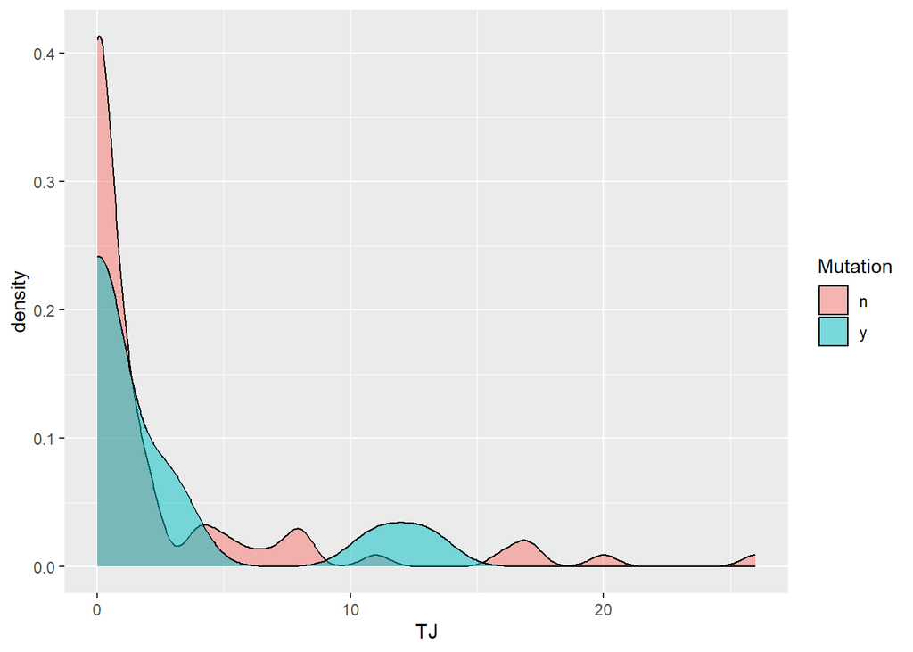

```r
RA %>%
  ggplot(aes(TJ, fill = Mutation))+geom_density(alpha = 0.5)
```

```r
#looks like a log transform would help, so check if data contains zeros first
RA %>%
  arrange(TJ) %>%
  select(Mutation, TJ)
```

```
## # A tibble: 98 × 2
##    Mutation    TJ
##    <chr>    <dbl>
##  1 n            0
##  2 n            0
##  3 n            0
##  4 n            0
##  5 n            0
##  6 n            0
##  7 n            0
##  8 n            0
##  9 n            0
## 10 n            0
## # ℹ 88 more rows
```

```r
#data does have lots of zeros, so can't log transform, run wilcox test
```

Wilcox test

```r
wilcox.test(TJ~Mutation, data = RA)
```

```
##
##  Wilcoxon rank sum test with continuity correction
##
## data:  TJ by Mutation
## W = 565.5, p-value = 0.7522
## alternative hypothesis: true location shift is not equal to 0
```

```r
wilcox.test(TJ~lowvafmut, data = RA)
```

```
##
##  Wilcoxon rank sum test with continuity correction
##
## data:  TJ by lowvafmut
## W = 1075, p-value = 0.7092
## alternative hypothesis: true location shift is not equal to 0
```

```r
wilcox.test(TJ~ymut, data = RA)
```

```
##
##  Wilcoxon rank sum test with continuity correction
##
## data:  TJ by ymut
## W = 1001.5, p-value = 0.9646
## alternative hypothesis: true location shift is not equal to 0
```

```r
wilcox.test(TJ~dmut, data = RA)
```

```
##
##  Wilcoxon rank sum test with continuity correction
##
## data:  TJ by dmut
## W = 819.5, p-value = 0.5392
## alternative hypothesis: true location shift is not equal to 0
```

```r
resultswcx <- tidy(wilcox.test(TJ~Mutation, data = RA, var.equal = TRUE)) %>%
  mutate(var = "Tender Joints") %>%
  rbind(resultswcx)

resultswcxlow <- tidy(wilcox.test(TJ~lowvafmut, data = RA, var.equal = TRUE)) %>%
  mutate(var = "Tender Joints") %>%
  rbind(resultswcxlow)
resultswcxy <- tidy(wilcox.test(TJ~ymut, data = RA, var.equal = TRUE)) %>%
  mutate(var = "Tender Joints") %>%
  rbind(resultswcxy)
resultswcxd <- tidy(wilcox.test(TJ~dmut, data = RA, var.equal = TRUE)) %>%
  mutate(var = "Tender Joints") %>%
  rbind(resultswcxd)
```

### pt_global T Test by Mutation

> Notes: couldn’t log transform because lots of zeros, ran wilcox on raw, saw no difference

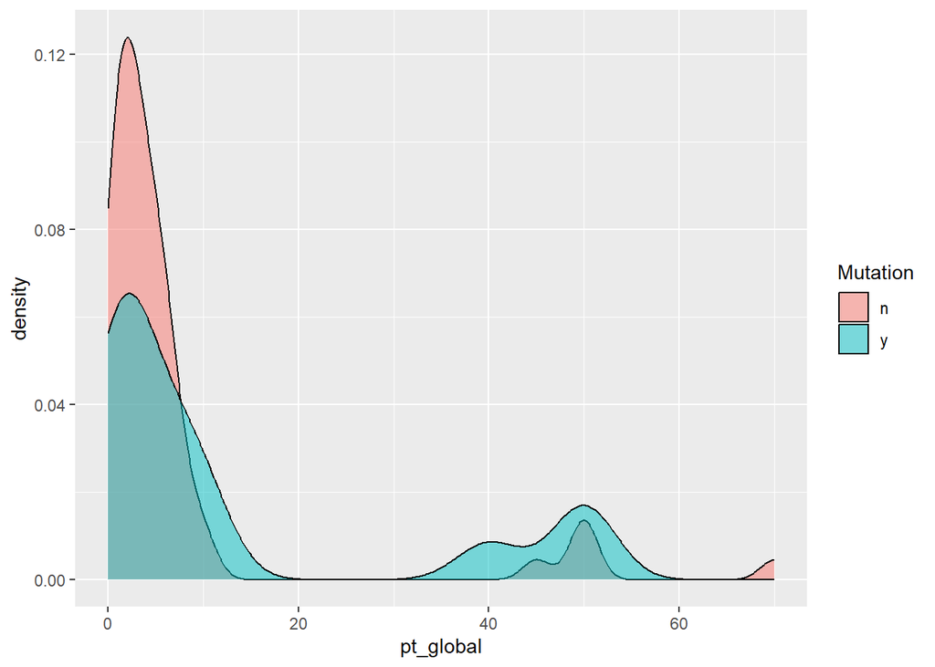

```r
RA %>%
  ggplot(aes(pt_global, fill = Mutation))+geom_density(alpha = 0.5)
```

```r
#looks like a log transform would help, so check if data contains zeros first
RA %>%
  arrange(pt_global) %>%
  select(Mutation, pt_global)
```

```
## # A tibble: 98 × 2
##    Mutation pt_global
##    <chr>        <dbl>
##  1 n                0
##  2 n                0
##  3 n                0
##  4 n                0
##  5 n                0
##  6 n                0
##  7 n                0
##  8 y                0
##  9 n                1
## 10 n                1
## # ℹ 88 more rows
```

```r
#data does have lots of zeros, so can't log transform, run wilcox test
```

Wilcox test

```r
wilcox.test(pt_global~Mutation, data = RA)
```

```
##
##  Wilcoxon rank sum test with continuity correction
##
## data:  pt_global by Mutation
## W = 357.5, p-value = 0.4382
## alternative hypothesis: true location shift is not equal to 0
```

```r
wilcox.test(pt_global~lowvafmut, data = RA)
```

```
##
##  Wilcoxon rank sum test with continuity correction
##
## data:  pt_global by lowvafmut
## W = 664.5, p-value = 0.9644
## alternative hypothesis: true location shift is not equal to 0
```

```r
wilcox.test(pt_global~ymut, data = RA)
```

```
##
##  Wilcoxon rank sum test with continuity correction
##
## data:  pt_global by ymut
## W = 645.5, p-value = 0.85
## alternative hypothesis: true location shift is not equal to 0
```

```r
wilcox.test(pt_global~dmut, data = RA)
```

```
##
##  Wilcoxon rank sum test with continuity correction
##
## data:  pt_global by dmut
## W = 532.5, p-value = 0.8101
## alternative hypothesis: true location shift is not equal to 0
```

```r
#making a table for wilcox p values
resultswcx <- tidy(wilcox.test(pt_global~Mutation, data = RA, var.equal = TRUE)) %>%
  mutate(var = "Patient Global") %>%
  rbind(resultswcx)

resultswcxlow <- tidy(wilcox.test(pt_global~lowvafmut, data = RA, var.equal = TRUE)) %>%
  mutate(var = "Patient Global") %>%
  rbind(resultswcxlow)
```

### pro_global T Test by Mutation

> Notes: couldn’t log transform because lots of zeros, ran wilcox on raw, saw no difference

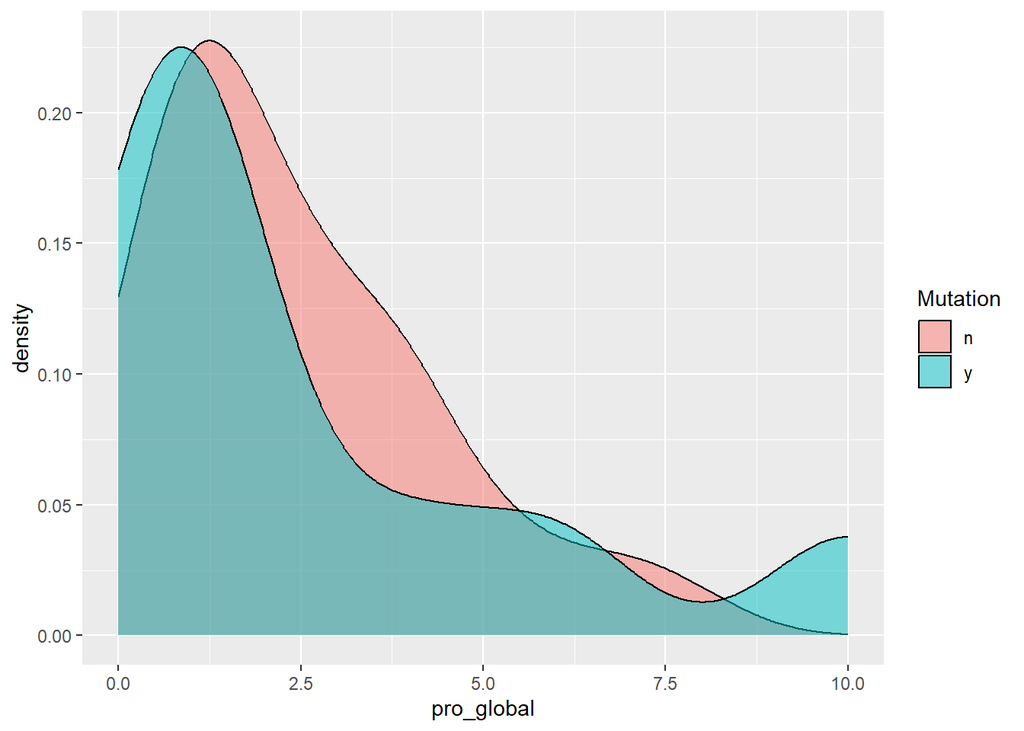

```r
RA %>%
  ggplot(aes(pro_global, fill = Mutation))+geom_density(alpha = 0.5)
```

```r
#looks like a log transform would help, so check if data contains zeros first
RA %>%
  arrange(pro_global) %>%
  select(Mutation, pro_global)
```

```
## # A tibble: 98 × 2
##    Mutation pro_global
##    <chr>         <dbl>
##  1 n                 0
##  2 n                 0
##  3 n                 0
##  4 n                 0
##  5 n                 0
##  6 n                 0
##  7 y                 0
##  8 y                 0
##  9 n                 1
## 10 n                 1
## # ℹ 88 more rows
```

```r
#data does have lots of zeros, so can't log transform, run wilcox test
```

Wilcox test

```r
wilcox.test(pro_global~Mutation, data = RA)
```

```
##
##  Wilcoxon rank sum test with continuity correction
##
## data:  pro_global by Mutation
## W = 296, p-value = 0.5577
## alternative hypothesis: true location shift is not equal to 0
```

```r
wilcox.test(pro_global~lowvafmut, data = RA)
```

```
##
##  Wilcoxon rank sum test with continuity correction
##
## data:  pro_global by lowvafmut
## W = 534, p-value = 0.5681
## alternative hypothesis: true location shift is not equal to 0
```

```r
wilcox.test(pro_global~ymut, data = RA)
```

```
##
##  Wilcoxon rank sum test with continuity correction
##
## data:  pro_global by ymut
## W = 569.5, p-value = 0.2387
## alternative hypothesis: true location shift is not equal to 0
```

```r
wilcox.test(pro_global~dmut, data = RA)
```

```
##
##  Wilcoxon rank sum test with continuity correction
##
## data:  pro_global by dmut
## W = 316, p-value = 0.4731
## alternative hypothesis: true location shift is not equal to 0
```

```r
#making a table for wilcox p values
resultswcx <- tidy(wilcox.test(pro_global~Mutation, data = RA, var.equal = TRUE)) %>%
  mutate(var = "Provider Global") %>%
  rbind(resultswcx)

#making a table for wilcox p values
resultswcxlow <- tidy(wilcox.test(pro_global~lowvafmut, data = RA, var.equal = TRUE)) %>%
  mutate(var = "Provider Global") %>%
  rbind(resultswcxlow)
#making a table for wilcox p values
resultswcxy <- tidy(wilcox.test(pro_global~ymut, data = RA, var.equal = TRUE)) %>%
  mutate(var = "Provider Global") %>%
  rbind(resultswcxy)
#making a table for wilcox p values
resultswcxd <- tidy(wilcox.test(pro_global~dmut, data = RA, var.equal = TRUE)) %>%
  mutate(var = "Provider Global") %>%
  rbind(resultswcxd)
```

### hopCCP T Test of Mutation

make a plot

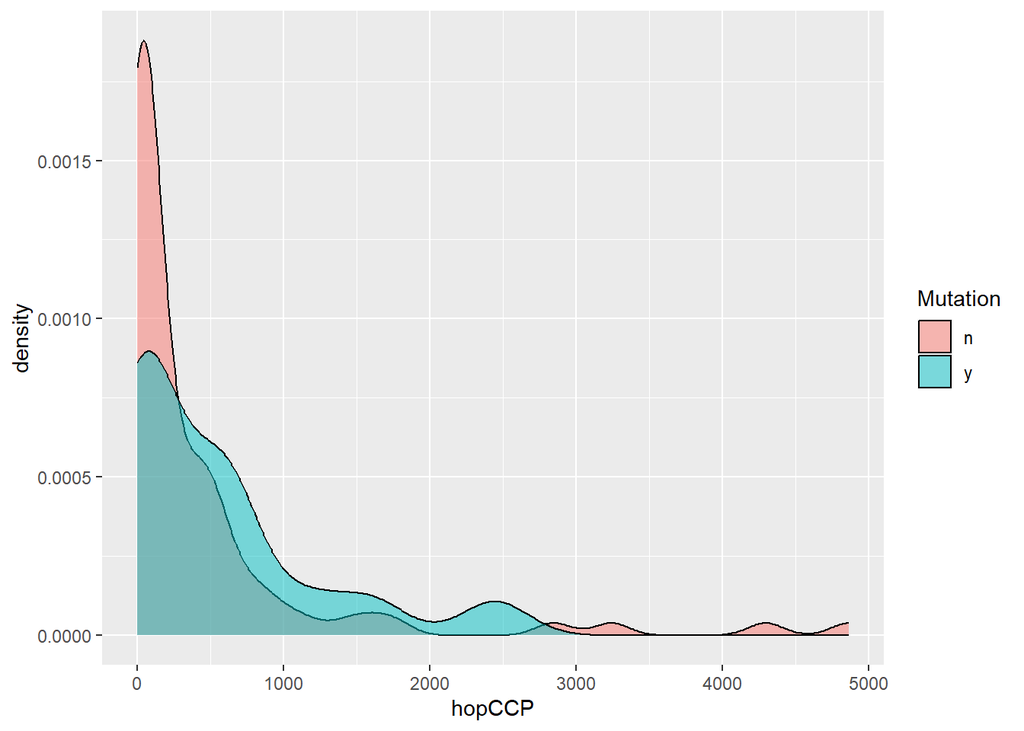

```r
RA %>%
  ggplot(aes(hopCCP, fill = Mutation))+geom_density(alpha = 0.5)
```

```r
#looks like a log transform would help
RA %>%
  arrange(hopCCP) %>%
  select(Mutation, hopCCP)
```

```
## # A tibble: 98 × 2
##    Mutation hopCCP
##    <chr>     <dbl>
##  1 y          2.58
##  2 n          3.44
##  3 n          4.32
##  4 n          4.50
##  5 n          4.54
##  6 n          4.93
##  7 n          5.16
##  8 n          5.19
##  9 n          5.22
## 10 n          5.66
## # ℹ 88 more rows
```

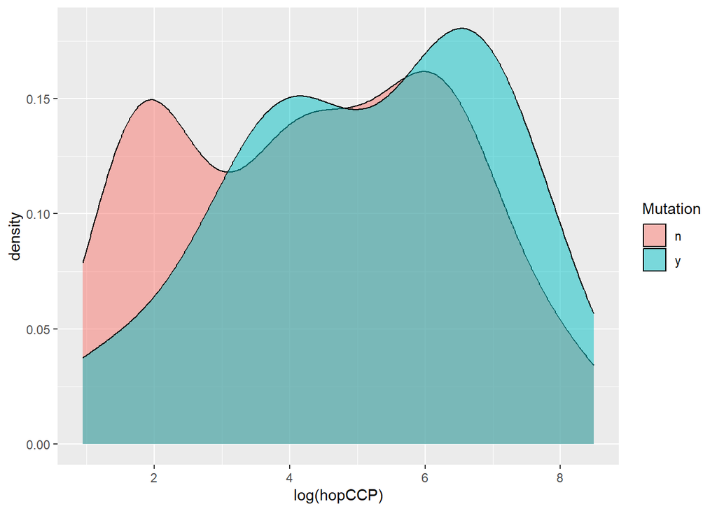

```r
#no zeros, so just take log
RA %>%
  ggplot(aes(log(hopCCP), fill = Mutation))+geom_density(alpha = 0.5)
```

create logccp

```r
RA <- RA %>%
  mutate(loghopccp = log(hopCCP))

#determine quantiles
RA %>%
  group_by(Mutation) %>%
  summarise(n= n(),
            q10 = quantile(hopCCP, probs = .10),
            q20 = quantile(hopCCP, probs = .20),
            q25 = quantile(hopCCP, probs = .25),
            q30 = quantile(hopCCP, probs = .30),
            q40 = quantile(hopCCP, probs = .40),
            q50 = quantile(hopCCP, probs = .50),
            q60 = quantile(hopCCP, probs = .60),
            q70 = quantile(hopCCP, probs = .70),
            q75 = quantile(hopCCP, probs = .75),
            q80 = quantile(hopCCP, probs = .80),
            q90 = quantile(hopCCP, probs = .90),
            )
```

```
## # A tibble: 2 × 13
##   Mutation     n   q10   q20   q25   q30   q40   q50   q60   q70   q75   q80
##   <chr>    <int> <dbl> <dbl> <dbl> <dbl> <dbl> <dbl> <dbl> <dbl> <dbl> <dbl>
## 1 n           82  5.67  7.03  9.58  19.0  48.1  94.3  188.  366.  456.  526.
## 2 y           16 19.5  38.8  47.0   54.7  71.1 306.   539.  605.  649.  704.
## # ℹ 1 more variable: q90 <dbl>
```

run equal variance t test normality looks ok and so does variance

```r
t.test(loghopccp~Mutation, data = RA, var.equal = TRUE)
```

```
##
##  Two Sample t-test
##
## data:  loghopccp by Mutation
## t = -1.1971, df = 96, p-value = 0.2342
## alternative hypothesis: true difference in means between group n and group y is not equal to 0
## 95 percent confidence interval:
##  -1.7667356  0.4374675
## sample estimates:
## mean in group n mean in group y
##        4.420353        5.084987
```

```r
wilcox.test(hopCCP~Mutation, data = RA)
```

```
##
##  Wilcoxon rank sum test with continuity correction
##
## data:  hopCCP by Mutation
## W = 515, p-value = 0.1769
## alternative hypothesis: true location shift is not equal to 0
```

```r
wilcox.test(hopCCP~lowvafmut, data = RA)
```

```
##
##  Wilcoxon rank sum test with continuity correction
##
## data:  hopCCP by lowvafmut
## W = 994, p-value = 0.1515
## alternative hypothesis: true location shift is not equal to 0
```

```r
wilcox.test(hopCCP~ymut, data = RA)
```

```
##
##  Wilcoxon rank sum test with continuity correction
##
## data:  hopCCP by ymut
## W = 821, p-value = 0.01245
## alternative hypothesis: true location shift is not equal to 0
```

```r
wilcox.test(hopCCP~dmut, data = RA)
```

```
##
##  Wilcoxon rank sum test with continuity correction
##
## data:  hopCCP by dmut
## W = 840, p-value = 0.5574
## alternative hypothesis: true location shift is not equal to 0
```

```r
#turning this into a dataset

resultswcx <- tidy(wilcox.test(hopCCP~Mutation, data = RA, var.equal = TRUE)) %>%
  mutate(var = "current CCP") %>%
  rbind(resultswcx)

resultswcxlow <- tidy(wilcox.test(hopCCP~lowvafmut, data = RA, var.equal = TRUE)) %>%
  mutate(var = "current CCP") %>%
  rbind(resultswcxlow)
resultswcxy <- tidy(wilcox.test(hopCCP~ymut, data = RA, var.equal = TRUE)) %>%
  mutate(var = "current CCP") %>%
  rbind(resultswcxy)
resultswcxd <- tidy(wilcox.test(hopCCP~dmut, data = RA, var.equal = TRUE)) %>%
  mutate(var = "current CCP") %>%
  rbind(resultswcxd)

#resultst <- tidy(t.test(loghopccp~Mutation, data = RA, var.equal = TRUE)) %>%
 # mutate(var = "current CCP") %>%
 # rbind(resultst)
```

### CRP T Test by Mutation

> Notes: Normality not met, log-transformed and ran t test with equal variance, not significant

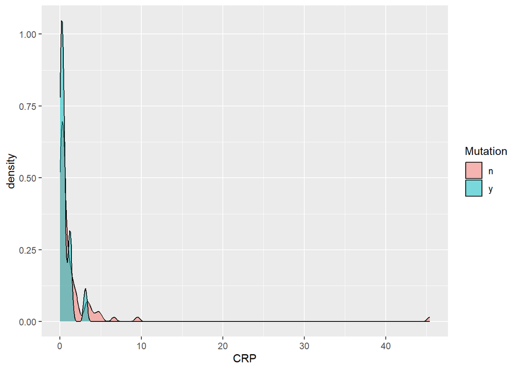

```r
RA %>%
  ggplot(aes(CRP, fill = Mutation))+geom_density(alpha = 0.5)
```

```r
#looks like a log transform would help
RA %>%
  arrange(CRP) %>%
  select(Mutation, CRP)
```

```
## # A tibble: 98 × 2
##    Mutation   CRP
##    <chr>    <dbl>
##  1 n          0
##  2 n          0
##  3 n          0
##  4 n          0
##  5 y          0
##  6 n          0.1
##  7 n          0.1
##  8 n          0.1
##  9 n          0.1
## 10 n          0.1
## # ℹ 88 more rows
```

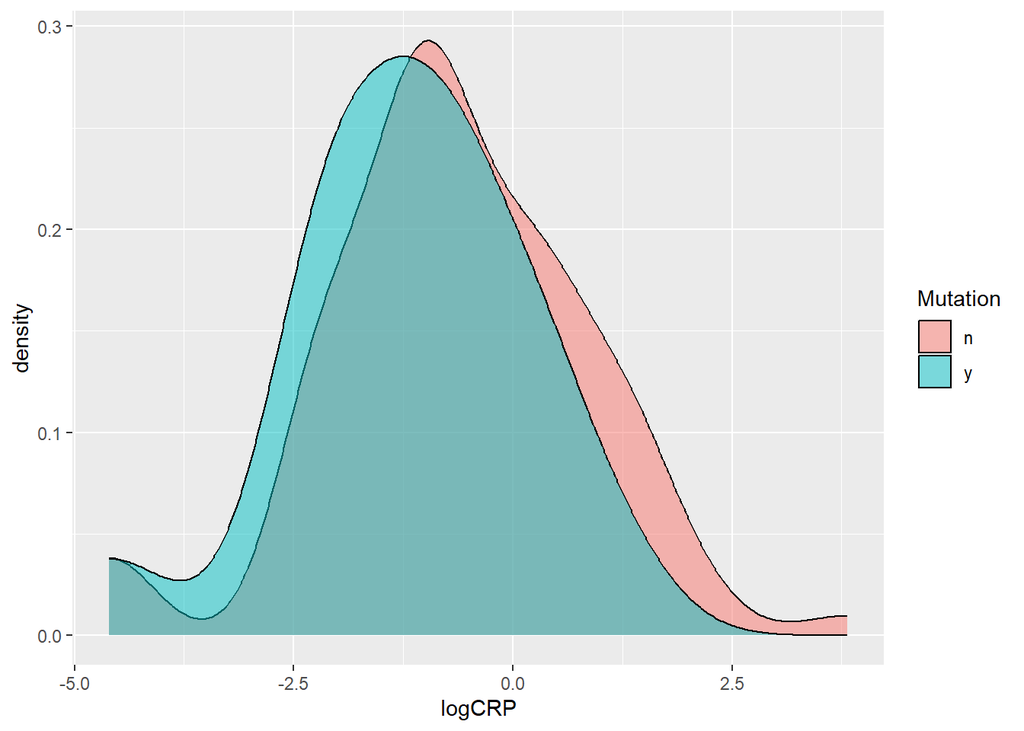

```r
#log transform and take care of zeros
RA <- RA %>%
  mutate(logCRP = log(CRP + 0.01))
##data does have zeros, so need to do additional modification before log transform
RA %>%
  ggplot(aes(logCRP, fill = Mutation))+geom_density(alpha = 0.5)
```

Run equal variance t test with the log data or use raw data and run wilcox test

```r
t.test(logCRP~Mutation, data = RA, var.equal = TRUE)
```

```
##
##  Two Sample t-test
##
## data:  logCRP by Mutation
## t = 1.2946, df = 96, p-value = 0.1986
## alternative hypothesis: true difference in means between group n and group y is not equal to 0
## 95 percent confidence interval:
##  -0.2841088  1.3495666
## sample estimates:
## mean in group n mean in group y
##      -0.6645838      -1.1973127
```

```r
t.test(logCRP~lowvafmut, data = RA, var.equal = TRUE)
```

```
##
##  Two Sample t-test
##
## data:  logCRP by lowvafmut
## t = 0.14378, df = 96, p-value = 0.886
## alternative hypothesis: true difference in means between group n and group y is not equal to 0
## 95 percent confidence interval:
##  -0.5659497  0.6543415
## sample estimates:
## mean in group n mean in group y
##      -0.7281091      -0.7723050
```

```r
t.test(logCRP~ymut, data = RA, var.equal = TRUE)
```

```
##
##  Two Sample t-test
##
## data:  logCRP by ymut
## t = 0.34888, df = 96, p-value = 0.7279
## alternative hypothesis: true difference in means between group n and group y is not equal to 0
## 95 percent confidence interval:
##  -0.5085223  0.7253958
## sample estimates:
## mean in group n mean in group y
##      -0.7061936      -0.8146303
```

```r
t.test(logCRP~dmut, data = RA, var.equal = TRUE)
```

```
##
##  Two Sample t-test
##
## data:  logCRP by dmut
## t = -0.45154, df = 96, p-value = 0.6526
## alternative hypothesis: true difference in means between group n and group y is not equal to 0
## 95 percent confidence interval:
##  -0.8566080  0.5391133
## sample estimates:
## mean in group n mean in group y
##      -0.7920567      -0.6333094
```

```r
#turning this into a dataset

resultst <- tidy(t.test(logCRP~Mutation, data = RA, var.equal = TRUE)) %>%
  mutate(var = "CRP") %>%
  rbind(resultst)

resultstlow <- tidy(t.test(logCRP~lowvafmut, data = RA, var.equal = TRUE)) %>%
  mutate(var = "CRP") %>%
  rbind(resultstlow)
resultsty <- tidy(t.test(logCRP~ymut, data = RA, var.equal = TRUE)) %>%
  mutate(var = "CRP") %>%
  rbind(resultsty)
resultstd <- tidy(t.test(logCRP~dmut, data = RA, var.equal = TRUE)) %>%
  mutate(var = "CRP") %>%
  rbind(resultstd)
```